# AadityaKumarRavi_Project_FMT

## AIML Module Project - Featurization, Model Selection and Tuning - Aaditya Kumar Ravi

***DOMAIN:*** Semiconductor manufacturing process  
***CONTEXT:*** A complex modern semiconductor manufacturing process is normally under constant surveillance via the monitoring of signals/variables collected from sensors and or process measurement points. However, not all of these signals are equally valuable in a specific monitoring system. The measured signals contain a combination of useful information, irrelevant information as well as noise. Engineers typically have a much larger number of signals than are actually required. If we consider each type of signal as a feature, then feature selection may be applied to identify the most relevant signals. The Process Engineers may then use these signals to determine key factors contributing to yield excursions downstream in the process. This will enable an increase in process throughput, decreased time to learning and reduce the per unit production costs. These signals can be used as features to predict the yield type. And by analysing and trying out different combinations of features, essential signals that are impacting the yield type can be identified.  
***DATA DESCRIPTION:*** signal-data.csv : (1567, 592)  
The data consists of 1567 datapoints each with 591 features.  
The dataset presented in this case represents a selection of such features where each example represents a single production entity with associated measured features and the labels represent a simple pass/fail yield for in house line testing. Target column “ –1” corresponds to a pass and “1” corresponds to a fail and the data time stamp is for that specific test point.  
***PROJECT OBJECTIVE:*** We will build a classifier to predict the Pass/Fail yield of a particular process entity and analyse whether all the features are required to build the model or not.  
***Steps and tasks: [Total Score: 60 points]***  
***1. Import and understand the data. [5 Marks]***

```python
import numpy as np
import pandas as pd
import matplotlib.pyplot as plt
%matplotlib inline
import seaborn as sns
```

#### A. Import ‘signal-data.csv’ as DataFrame. [2 Marks]

```python
signal_df = pd.read_csv('signal-data.csv')
```

```python
signal_df.info()
```

```
<class 'pandas.core.frame.DataFrame'>
RangeIndex: 1567 entries, 0 to 1566
Columns: 592 entries, Time to Pass/Fail
dtypes: float64(590), int64(1), object(1)
memory usage: 7.1+ MB
```

```python
signal_df.shape
```

```
(1567, 592)
```

- This dataframe has 1567 rows and 592 columns which is very large in number
- 590 columns have Values in float64, 1 column has int64 values and 1 columns has object type values.

```python
signal_df.head()
```

|  | Time | 0 | 1 | 2 | 3 | 4 | 5 | 6 | 7 | 8 | ... | 581 | 582 | 583 | 584 | 585 | 586 | 587 | 588 | 589 | Pass/Fail |
| --- | --- | --- | --- | --- | --- | --- | --- | --- | --- | --- | --- | --- | --- | --- | --- | --- | --- | --- | --- | --- | --- |
| 0 | 2008-07-19 11:55:00 | 3030.93 | 2564.00 | 2187.7333 | 1411.1265 | 1.3602 | 100.0 | 97.6133 | 0.1242 | 1.5005 | ... | NaN | 0.5005 | 0.0118 | 0.0035 | 2.3630 | NaN | NaN | NaN | NaN | -1 |
| 1 | 2008-07-19 12:32:00 | 3095.78 | 2465.14 | 2230.4222 | 1463.6606 | 0.8294 | 100.0 | 102.3433 | 0.1247 | 1.4966 | ... | 208.2045 | 0.5019 | 0.0223 | 0.0055 | 4.4447 | 0.0096 | 0.0201 | 0.0060 | 208.2045 | -1 |
| 2 | 2008-07-19 13:17:00 | 2932.61 | 2559.94 | 2186.4111 | 1698.0172 | 1.5102 | 100.0 | 95.4878 | 0.1241 | 1.4436 | ... | 82.8602 | 0.4958 | 0.0157 | 0.0039 | 3.1745 | 0.0584 | 0.0484 | 0.0148 | 82.8602 | 1 |
| 3 | 2008-07-19 14:43:00 | 2988.72 | 2479.90 | 2199.0333 | 909.7926 | 1.3204 | 100.0 | 104.2367 | 0.1217 | 1.4882 | ... | 73.8432 | 0.4990 | 0.0103 | 0.0025 | 2.0544 | 0.0202 | 0.0149 | 0.0044 | 73.8432 | -1 |
| 4 | 2008-07-19 15:22:00 | 3032.24 | 2502.87 | 2233.3667 | 1326.5200 | 1.5334 | 100.0 | 100.3967 | 0.1235 | 1.5031 | ... | NaN | 0.4800 | 0.4766 | 0.1045 | 99.3032 | 0.0202 | 0.0149 | 0.0044 | 73.8432 | -1 |

5 rows × 592 columns

```python
signal_df['Time'].dtypes
```

```
dtype('O')
```

```python
signal_df['Pass/Fail'].dtypes
```

```
dtype('int64')
```

- Time feature is of object datatype
- pass/Fail feature is of int type
- Rest all columns are of float type

#### B. Print 5 point summary and share at least 2 observations. [3 Marks]

```python
pd.set_option('display.max_rows', None)
signal_df.describe().loc[['min','25%','50%','75%','max']].T
```

|  | min | 25% | 50% | 75% | max |
| --- | --- | --- | --- | --- | --- |
| 0 | 2743.2400 | 2966.260000 | 3011.49000 | 3056.650000 | 3356.3500 |
| 1 | 2158.7500 | 2452.247500 | 2499.40500 | 2538.822500 | 2846.4400 |
| 2 | 2060.6600 | 2181.044400 | 2201.06670 | 2218.055500 | 2315.2667 |
| 3 | 0.0000 | 1081.875800 | 1285.21440 | 1591.223500 | 3715.0417 |
| 4 | 0.6815 | 1.017700 | 1.31680 | 1.525700 | 1114.5366 |
| 5 | 100.0000 | 100.000000 | 100.00000 | 100.000000 | 100.0000 |
| 6 | 82.1311 | 97.920000 | 101.51220 | 104.586700 | 129.2522 |
| 7 | 0.0000 | 0.121100 | 0.12240 | 0.123800 | 0.1286 |
| 8 | 1.1910 | 1.411200 | 1.46160 | 1.516900 | 1.6564 |
| 9 | -0.0534 | -0.010800 | -0.00130 | 0.008400 | 0.0749 |
| 10 | -0.0349 | -0.005600 | 0.00040 | 0.005900 | 0.0530 |
| 11 | 0.6554 | 0.958100 | 0.96580 | 0.971300 | 0.9848 |
| 12 | 182.0940 | 198.130700 | 199.53560 | 202.007100 | 272.0451 |
| 13 | 0.0000 | 0.000000 | 0.00000 | 0.000000 | 0.0000 |
| 14 | 2.2493 | 7.094875 | 8.96700 | 10.861875 | 19.5465 |
| 15 | 333.4486 | 406.127400 | 412.21910 | 419.089275 | 824.9271 |
| 16 | 4.4696 | 9.567625 | 9.85175 | 10.128175 | 102.8677 |
| 17 | 0.5794 | 0.968200 | 0.97260 | 0.976800 | 0.9848 |
| 18 | 169.1774 | 188.299825 | 189.66420 | 192.189375 | 215.5977 |
| 19 | 9.8773 | 12.460000 | 12.49960 | 12.547100 | 12.9898 |
| 20 | 1.1797 | 1.396500 | 1.40600 | 1.415000 | 1.4534 |
| 21 | -7150.2500 | -5933.250000 | -5523.25000 | -5356.250000 | 0.0000 |
| 22 | 0.0000 | 2578.000000 | 2664.00000 | 2841.750000 | 3656.2500 |
| 23 | -9986.7500 | -4371.750000 | -3820.75000 | -3352.750000 | 2363.0000 |
| 24 | -14804.5000 | -1476.000000 | -78.75000 | 1377.250000 | 14106.0000 |
| 25 | 0.0000 | 1.094800 | 1.28300 | 1.304300 | 1.3828 |
| 26 | 0.0000 | 1.906500 | 1.98650 | 2.003200 | 2.0528 |
| 27 | 0.0000 | 5.263700 | 7.26470 | 7.329700 | 7.6588 |
| 28 | 59.4000 | 67.377800 | 69.15560 | 72.266700 | 77.9000 |
| 29 | 0.6667 | 2.088900 | 2.37780 | 2.655600 | 3.5111 |

[output cut: 561 more lines]

**Observations:**

- The minimum, Q1, median, and Q3 values are all the same -1 for Pass/Fail feature which indicates that at least 75% of the data falls at this value. It means that the dataset feature Pass/Fail is heavily skewed towards one value -1 i.e imbalanced.
- Column 5 has all min, 25%, 50%, 75%, max values same i.e 100, which indicates it has only one value i.e 100. This can be removed as it does not provide any discriminatory or useful information for modeling or analysis.
- Column 13,52,97, 141, 149, 178-179,186,189 to 194,226,229 to 237,240 to 243,256 to 266,284,313 to 315, 322, 325 to 330, 364, 369 to 375, 378 to 381, 394 to 404, 414, 422, 449 to 451, 458, 461 to 466, 481, 498, 501 to 509, 512 to 515, 528 to 538 also has all values 0, which indicates it has only one value i.e 0. This can also be removed for the same reason as above.

```python
signal_df['Pass/Fail'].value_counts(normalize=True)
```

```
Pass/Fail
-1    0.933631
 1    0.066369
Name: proportion, dtype: float64
```

```python
signal_df['5'].value_counts()
```

```
5
100.0    1553
Name: count, dtype: int64
```

##### 2. Data cleansing: [15 Marks]

##### A. Write a for loop which will remove all the features with 20%+ Null values and impute rest with mean of the feature. [5 Marks]

```python
signal_df.shape
```

```
(1567, 592)
```

- We have 3 types of values in the dataset object, int, float. so it is not possible to find mean of object type. hence we will exclude object datatype while finding mean and replacing with mean of the column.
- We have total 592 features before removal.

```python
for col in signal_df.columns:
    missing_perc = signal_df[col].isnull().mean()*100
    if missing_perc > 20:  #20%+ missing values check
        signal_df.drop(col, axis=1, inplace=True)
    else:
        if signal_df[col].dtype!='O':  #excluding object type
            col_mean = signal_df[col].mean()
            signal_df[col].fillna(col_mean, inplace=True)
```

```python
#After removing columns with 20%+ null values and imputing rest with mean, Let us view the percentage count
pd.set_option('display.max_rows', None)
signal_df.isnull().mean()*100
```

```
Time         0.0
0            0.0
1            0.0
2            0.0
3            0.0
4            0.0
5            0.0
6            0.0
7            0.0
8            0.0
9            0.0
10           0.0
11           0.0
12           0.0
13           0.0
```

[output cut: 546 more lines]

```python
pd.reset_option('display.max_rows')
```

```python
signal_df.shape
```

```
(1567, 560)
```

- We can see all the columns having 20%+ missing values are removed. and rest are replaced with its column mean
- Now we have only 560 columns left out of 592 as 32 columns got removed due to having 20%+ missing values

#### B. Identify and drop the features which are having same value for all the rows. [3 Marks]

```python
signal_df.duplicated().sum()
```

```
0
```

There is no duplicate rows found, Let us check after removing 1st column from the search as Time can not be same.

```python
signal_df.iloc[:,1:].duplicated().sum()
```

```
0
```

- Still we don't find any duplicate value, it looks like there is no more than 1 row with same values for entire columns, meaning there is no duplicate rows for all features together.
- Now let us identify those features individually which are having same values for all the rows.

```python
for col in signal_df.columns:
    #Get how many unique values are there for particular column, if the column has only one value for all rows it means the column has duplicated value for that column.
    #we will drop those columns
    col_value_count = signal_df[col].nunique()
    if col_value_count==1:
        signal_df.drop(col, axis=1, inplace=True)
```

```python
signal_df.shape
```

```
(1567, 444)
```

```python
signal_df
```

|  | Time | 0 | 1 | 2 | 3 | 4 | 6 | 7 | 8 | 9 | ... | 577 | 582 | 583 | 584 | 585 | 586 | 587 | 588 | 589 | Pass/Fail |
| --- | --- | --- | --- | --- | --- | --- | --- | --- | --- | --- | --- | --- | --- | --- | --- | --- | --- | --- | --- | --- | --- |
| 0 | 2008-07-19 11:55:00 | 3030.93 | 2564.00 | 2187.7333 | 1411.1265 | 1.3602 | 97.6133 | 0.1242 | 1.500500 | 0.016200 | ... | 14.9509 | 0.5005 | 0.0118 | 0.0035 | 2.3630 | 0.021458 | 0.016475 | 0.005283 | 99.670066 | -1 |
| 1 | 2008-07-19 12:32:00 | 3095.78 | 2465.14 | 2230.4222 | 1463.6606 | 0.8294 | 102.3433 | 0.1247 | 1.496600 | -0.000500 | ... | 10.9003 | 0.5019 | 0.0223 | 0.0055 | 4.4447 | 0.009600 | 0.020100 | 0.006000 | 208.204500 | -1 |
| 2 | 2008-07-19 13:17:00 | 2932.61 | 2559.94 | 2186.4111 | 1698.0172 | 1.5102 | 95.4878 | 0.1241 | 1.443600 | 0.004100 | ... | 9.2721 | 0.4958 | 0.0157 | 0.0039 | 3.1745 | 0.058400 | 0.048400 | 0.014800 | 82.860200 | 1 |
| 3 | 2008-07-19 14:43:00 | 2988.72 | 2479.90 | 2199.0333 | 909.7926 | 1.3204 | 104.2367 | 0.1217 | 1.488200 | -0.012400 | ... | 8.5831 | 0.4990 | 0.0103 | 0.0025 | 2.0544 | 0.020200 | 0.014900 | 0.004400 | 73.843200 | -1 |
| 4 | 2008-07-19 15:22:00 | 3032.24 | 2502.87 | 2233.3667 | 1326.5200 | 1.5334 | 100.3967 | 0.1235 | 1.503100 | -0.003100 | ... | 10.9698 | 0.4800 | 0.4766 | 0.1045 | 99.3032 | 0.020200 | 0.014900 | 0.004400 | 73.843200 | -1 |
| ... | ... | ... | ... | ... | ... | ... | ... | ... | ... | ... | ... | ... | ... | ... | ... | ... | ... | ... | ... | ... | ... |
| 1562 | 2008-10-16 15:13:00 | 2899.41 | 2464.36 | 2179.7333 | 3085.3781 | 1.4843 | 82.2467 | 0.1248 | 1.342400 | -0.004500 | ... | 11.7256 | 0.4988 | 0.0143 | 0.0039 | 2.8669 | 0.006800 | 0.013800 | 0.004700 | 203.172000 | -1 |
| 1563 | 2008-10-16 20:49:00 | 3052.31 | 2522.55 | 2198.5667 | 1124.6595 | 0.8763 | 98.4689 | 0.1205 | 1.433300 | -0.006100 | ... | 17.8379 | 0.4975 | 0.0131 | 0.0036 | 2.6238 | 0.006800 | 0.013800 | 0.004700 | 203.172000 | -1 |
| 1564 | 2008-10-17 05:26:00 | 2978.81 | 2379.78 | 2206.3000 | 1110.4967 | 0.8236 | 99.4122 | 0.1208 | 1.462862 | -0.000841 | ... | 17.7267 | 0.4987 | 0.0153 | 0.0041 | 3.0590 | 0.019700 | 0.008600 | 0.002500 | 43.523100 | -1 |
| 1565 | 2008-10-17 06:01:00 | 2894.92 | 2532.01 | 2177.0333 | 1183.7287 | 1.5726 | 98.7978 | 0.1213 | 1.462200 | -0.007200 | ... | 19.2104 | 0.5004 | 0.0178 | 0.0038 | 3.5662 | 0.026200 | 0.024500 | 0.007500 | 93.494100 | -1 |
| 1566 | 2008-10-17 06:07:00 | 2944.92 | 2450.76 | 2195.4444 | 2914.1792 | 1.5978 | 85.1011 | 0.1235 | 1.462862 | -0.000841 | ... | 22.9183 | 0.4987 | 0.0181 | 0.0040 | 3.6275 | 0.011700 | 0.016200 | 0.004500 | 137.784400 | -1 |

1567 rows × 444 columns

We can see 116 columns are dropped. previously the column count was 560 and now it is 444

#### C. Drop other features if required using relevant functional knowledge. Clearly justify the same. [2 Marks]

#### D. Check for multi-collinearity in the data and take necessary action. [3 Marks]

- Still we have 444 columns present in the dataset which is quite high. Having a large number of features can lead to several challenges including increased computational complexity, difficulty in visualization, overfitting, and decreased interpretability. Hence, we should try to reduce the number of features to improve model performance and efficiency.
- Let us drop those columns whose standard deviation is 0 as columns with 0 standard deviation remains constant for all and is not much useful for model building.

```python
std_dev = signal_df.iloc[:,1:].std() #excluded 1st feature as that is of object type
cols_with_zero_std = std_dev[std_dev==0].index
cols_with_zero_std
```

```
Index([], dtype='object')
```

there are no columns with standard deviation zero, otherwise we would have dropped them as it does not give any useful information for model building.

```python
#signal_df.drop(cols_with_zero_std, axis=1, inplace=True)
```

```python
signal_df.shape
```

```
(1567, 444)
```

- Let us check if there is high correlation between any columns. we may drop those columns which has high correlation with more than equal 8 other columns.
- Commonly used threshold for considering correlations as high is 0.7 to 0.9 for positive and -0.7 to -0.9 for negative. we are not taking 1 correlation value here as we are excluding self correlation. diagonal(self) correlation are always 1.

```python
corr_matrix = signal_df.select_dtypes(exclude=['object']).corr()
corr_matrix
```

|  | 0 | 1 | 2 | 3 | 4 | 6 | 7 | 8 | 9 | 10 | ... | 577 | 582 | 583 | 584 | 585 | 586 | 587 | 588 | 589 | Pass/Fail |
| --- | --- | --- | --- | --- | --- | --- | --- | --- | --- | --- | --- | --- | --- | --- | --- | --- | --- | --- | --- | --- | --- |
| 0 | 1.000000 | -0.143840 | 0.004756 | -0.007613 | -0.011014 | 0.002270 | 0.031483 | -0.052622 | 0.009045 | 0.006504 | ... | 0.008601 | 0.000224 | 0.023453 | 0.019907 | 0.023589 | 0.018443 | -0.025880 | -0.028166 | 0.004174 | -0.025141 |
| 1 | -0.143840 | 1.000000 | 0.005767 | -0.007568 | -0.001636 | -0.025564 | -0.012037 | 0.031258 | 0.023964 | 0.009645 | ... | -0.010145 | 0.043556 | 0.002904 | -0.001264 | 0.002273 | -0.009403 | 0.017266 | 0.010118 | 0.044797 | -0.002603 |
| 2 | 0.004756 | 0.005767 | 1.000000 | 0.298935 | 0.095891 | -0.136225 | -0.146213 | 0.023528 | 0.016168 | 0.069893 | ... | -0.028705 | -0.006023 | 0.015697 | 0.018225 | 0.015752 | -0.025495 | -0.029345 | -0.030818 | -0.032890 | -0.000957 |
| 3 | -0.007613 | -0.007568 | 0.298935 | 1.000000 | -0.058483 | -0.685835 | 0.073856 | -0.102892 | 0.068215 | 0.049873 | ... | 0.016438 | 0.008988 | 0.025436 | 0.024736 | 0.026019 | 0.034711 | -0.039132 | -0.033645 | -0.080341 | -0.024623 |
| 4 | -0.011014 | -0.001636 | 0.095891 | -0.058483 | 1.000000 | -0.074368 | -0.347734 | -0.025946 | 0.054206 | -0.006470 | ... | -0.004070 | 0.045081 | -0.001300 | -0.001597 | -0.001616 | -0.043929 | -0.031005 | -0.026100 | 0.050910 | -0.013756 |
| ... | ... | ... | ... | ... | ... | ... | ... | ... | ... | ... | ... | ... | ... | ... | ... | ... | ... | ... | ... | ... | ... |
| 586 | 0.018443 | -0.009403 | -0.025495 | 0.034711 | -0.043929 | -0.041209 | 0.058113 | 0.010433 | 0.033738 | 0.000327 | ... | -0.002684 | -0.016726 | 0.002257 | 0.001605 | 0.002743 | 1.000000 | 0.167913 | 0.164238 | -0.486559 | 0.004156 |
| 587 | -0.025880 | 0.017266 | -0.029345 | -0.039132 | -0.031005 | 0.034027 | -0.021426 | 0.022845 | 0.059301 | 0.046965 | ... | -0.009405 | -0.024473 | -0.002649 | -0.002498 | -0.002930 | 0.167913 | 1.000000 | 0.974276 | 0.390813 | 0.035391 |
| 588 | -0.028166 | 0.010118 | -0.030818 | -0.033645 | -0.026100 | 0.032227 | -0.020893 | 0.026250 | 0.060758 | 0.046048 | ... | -0.015596 | -0.020705 | -0.002260 | -0.001957 | -0.002530 | 0.164238 | 0.974276 | 1.000000 | 0.389211 | 0.031167 |
| 589 | 0.004174 | 0.044797 | -0.032890 | -0.080341 | 0.050910 | 0.043777 | -0.107804 | -0.022770 | 0.004880 | 0.008393 | ... | -0.024766 | 0.041486 | -0.003008 | -0.003295 | -0.003800 | -0.486559 | 0.390813 | 0.389211 | 1.000000 | -0.002653 |
| Pass/Fail | -0.025141 | -0.002603 | -0.000957 | -0.024623 | -0.013756 | 0.016239 | 0.012991 | 0.028016 | -0.031191 | 0.033639 | ... | -0.049633 | 0.047020 | 0.005981 | 0.005419 | 0.005034 | 0.004156 | 0.035391 | 0.031167 | -0.002653 | 1.000000 |

443 rows × 443 columns

```python
high_corr_indices = []

#Iterate over the elements of the correlation matrix up to the diagonal only, becuase beyond diagonal elements are repeated.
for i in range(len(corr_matrix)):
    for j in range(i):
        if abs(corr_matrix.iloc[i, j]) > 0.7: #assuming 0.7 or above is higher correlation (+ve and -ve)
            high_corr_indices.append((corr_matrix.index[i], corr_matrix.columns[j]))

print(high_corr_indices) #print indices having high correlation
```

```
[('17', '11'), ('22', '21'), ('26', '25'), ('27', '25'), ('27', '26'), ('30', '29'), ('34', '32'), ('35', '34'), ('36', '32'), ('36', '34'), ('36', '35'), ('39', '34'), ('39', '36'), ('46', '45'), ('50', '46'), ('51', '47'), ('54', '53'), ('60', '43'), ('60', '50'), ('65', '64'), ('66', '46'), ('66'…
```

```python
count_dict = {}
for pair in high_corr_indices:
    x_value = pair[0]  #Get the first element x of the pair
    count_dict[x_value] = count_dict.get(x_value, 0) + 1  #Increment the count for the x value

for x_value, count in count_dict.items():
    print(x_value, "occurs", count, "times")
    if count>=8: #Here we are assuming 8 columns as threshold for correlation with other columns as we have most of the columns are correlated for less than 8 times,
                 #a few are having more than 8 correlations and I checked they are representing almost similar information.
                 #Hence considering that we need to reduce the correlations, dimension reduction and redundant data, Choosing 8 here.
        signal_df.drop(x_value, axis=1, inplace=True) #dropping columns having high correlation with more than equal to 8 columns

print(signal_df.shape)
```

```
17 occurs 1 times
22 occurs 1 times
26 occurs 1 times
27 occurs 2 times
30 occurs 1 times
34 occurs 1 times
35 occurs 1 times
36 occurs 3 times
39 occurs 2 times
46 occurs 1 times
50 occurs 1 times
51 occurs 1 times
54 occurs 1 times
60 occurs 2 times
65 occurs 1 times
```

[output cut: 227 more lines]

We can see it has dropped 28 columns from 444 columns to 416.

- Let us try Lasso regularization method because Lasso regression is particularly useful when dealing with high-dimensional datasets with many irrelevant or redundant features. It can automatically perform feature selection and create simpler, more interpretable models.
- it can indirectly address multicollinearity by forcing some coefficients to be exactly zero, effectively selecting a subset of features and reducing the effective dimensionality of the problem.

```python
from sklearn.linear_model import Lasso, Ridge
from sklearn.model_selection import train_test_split
from sklearn import preprocessing

X=signal_df.drop(['Time','Pass/Fail'], axis=1)
Y=signal_df['Pass/Fail']

X_scaled = preprocessing.scale(X)
Y_scaled = preprocessing.scale(Y)

X_train, X_test, Y_train, Y_test = train_test_split(X_scaled, Y_scaled, test_size=0.25, random_state=1)

#We will try different values of alpha and will pick one with best training and test score among that.
alphas = np.logspace(-4, 2, 100)
for a in alphas:
    lasso = Lasso(alpha=a)
    lasso.fit(X_train,Y_train)
    coeff = lasso.coef_
    print("=========Alpha:",a,"===============")
    print("Lasso Train Score:",lasso.score(X_train, Y_train))
    print("Lasso Test Score",lasso.score(X_test, Y_test))
    print("Lasso coefficients(Not Zero):",coeff[coeff!=0])
```

[output not shown]

[output cut: 3010 more lines]

```
Lasso Train Score: 0.0
Lasso Test Score -5.145369041947845e-08
Lasso coefficients(Not Zero): []
=========Alpha: 75.64633275546291 ===============
Lasso Train Score: 0.0
Lasso Test Score -5.145369041947845e-08
Lasso coefficients(Not Zero): []
=========Alpha: 86.97490026177834 ===============
Lasso Train Score: 0.0
Lasso Test Score -5.145369041947845e-08
Lasso coefficients(Not Zero): []
=========Alpha: 100.0 ===============
Lasso Train Score: 0.0
Lasso Test Score -5.145369041947845e-08
Lasso coefficients(Not Zero): []
```

```python
#Best value of alpha found among above train and test score is 0.030538555088334154
lasso = Lasso(alpha=0.0306)
lasso.fit(X_train,Y_train)
coeff = lasso.coef_
print("=========Alpha:0.0306===============")
print("Lasso Train Score:",lasso.score(X_train, Y_train))
print("Lasso Test Score",lasso.score(X_test, Y_test))
print("Lasso coefficients(Not Zero):",coeff[coeff!=0])
print("Lasso coefficients(with Zero):",coeff)
```

```
=========Alpha:0.0306===============
Lasso Train Score: 0.15844163369711994
Lasso Test Score 0.0019517246812397193
Lasso coefficients(Not Zero): [-0.00683754 -0.00139839 -0.01138861  0.04066213 -0.00149183 -0.00359476
 -0.01547351 -0.01107198  0.12318265  0.0425498  -0.03723855  0.00746231
  0.02694651  0.0186193   0.01805341  0.029766    0.02124408 -0.0131431
  0.00931079  0.00941428  0.04211458  0.0462552   0.0303393   0.0103107
 -0.02241393 -0.01429041 -0.0002028  -0.017312    0.01923413  0.02610121
 -0.03481607  0.01248881 -0.00462768  0.14427495 -0.00975034 -0.02409759
  0.02845632 -0.00686146  0.06891687  0.0426287   0.01403937  0.00559586
 -0.00169007  0.0004231  -0.00964224  0.0117286   0.0470381   0.04160316
 -0.02071779 -0.00649461 -0.00442914 -0.02105702  0.01637905  0.0511884
  0.01544882  0.0120989  -0.0160838   0.04265908  0.00304238 -0.00919968
  0.02405373 -0.00154447 -0.02730537  0.01400263]
Lasso coefficients(with Zero): [ 0.          0.         -0.00683754 -0.         -0.          0.
  0.          0.         -0.00139839  0.         -0.          0.
 -0.01138861  0.         -0.          0.          0.          0.
  0.          0.04066213 -0.00149183 -0.         -0.00359476  0.
 -0.          0.         -0.         -0.         -0.         -0.01547351
  0.          0.         -0.         -0.          0.          0.
 -0.         -0.         -0.01107198 -0.         -0.         -0.
  0.          0.          0.         -0.          0.          0.
  0.         -0.         -0.          0.          0.          0.
  0.12318265 -0.          0.         -0.         -0.          0.0425498
  0.         -0.         -0.03723855 -0.         -0.          0.00746231
 -0.          0.02694651 -0.         -0.          0.         -0.
 -0.          0.0186193   0.         -0.         -0.          0.01805341
 -0.          0.          0.         -0.          0.         -0.
  0.         -0.         -0.         -0.         -0.          0.029766
  0.02124408 -0.         -0.0131431   0.00931079 -0.         -0.
 -0.         -0.         -0.          0.          0.00941428 -0.
 -0.         -0.         -0.         -0.         -0.          0.04211458
 -0.          0.          0.         -0.          0.         -0.
 -0.          0.0462552   0.0303393   0.0103107  -0.02241393  0.
 -0.         -0.          0.          0.         -0.         -0.
 -0.         -0.         -0.         -0.         -0.         -0.
  0.         -0.         -0.         -0.         -0.          0.
  0.         -0.01429041  0.          0.          0.         -0.0002028
 -0.          0.          0.          0.          0.          0.
  0.          0.         -0.         -0.          0.          0.
```

[output cut: 28 more lines]

```
 -0.         -0.         -0.          0.         -0.         -0.
 -0.          0.04160316  0.         -0.          0.          0.
  0.         -0.         -0.         -0.02071779 -0.         -0.
 -0.00649461 -0.00442914  0.          0.         -0.02105702  0.
 -0.          0.          0.          0.          0.         -0.
 -0.         -0.          0.01637905  0.0511884   0.01544882 -0.
 -0.         -0.         -0.         -0.          0.         -0.
 -0.         -0.          0.          0.0120989   0.         -0.
 -0.         -0.         -0.          0.         -0.0160838  -0.
  0.          0.         -0.          0.          0.         -0.
  0.          0.04265908  0.00304238  0.          0.          0.
 -0.00919968 -0.         -0.          0.         -0.          0.
 -0.          0.02405373  0.         -0.00154447 -0.         -0.
 -0.         -0.02730537 -0.         -0.          0.          0.
  0.          0.          0.          0.01400263  0.         -0.        ]
```

```python
#count of coeffients not equal to zero
len(coeff[coeff!=0])
```

```
64
```

```python
signal_df.shape
```

```
(1567, 416)
```

**Let us drop the columns with coefficient as zero, so we will have only 64+2=66(Time, Pass/Fail) columns remaining after removal out of 416 columns as we have 64 columns whose coefficients are not zero. So 350 columns will be droped**

```python
zero_columns_idx = [idx+1 for idx, coef in enumerate(coeff) if abs(coef)==0] #Here we are taking idx+1 because first column is Time in Signal_df which is not in coeff, so we are adding 1 so that 0th index of coeff will be used to delete 1st index of signal_df as it has Time column on 0th index and we want to skip that from deletion.
signal_df.drop(signal_df.columns[zero_columns_idx], axis=1, inplace=True)
signal_df.shape
```

```
(1567, 66)
```

```python
signal_df
```

|  | Time | 2 | 9 | 14 | 21 | 22 | 24 | 31 | 40 | 59 | ... | 541 | 548 | 557 | 558 | 562 | 569 | 571 | 575 | 587 | Pass/Fail |
| --- | --- | --- | --- | --- | --- | --- | --- | --- | --- | --- | --- | --- | --- | --- | --- | --- | --- | --- | --- | --- | --- |
| 0 | 2008-07-19 11:55:00 | 2187.7333 | 0.016200 | 7.955800 | -5419.00 | 2916.50 | 751.00 | 3.5191 | 61.29 | -1.7264 | ... | 11.507400 | 75.752 | 1.0297 | 1.0344 | 262.729683 | 21.117674 | 2.1113 | 0.1026 | 0.016475 | -1 |
| 1 | 2008-07-19 12:32:00 | 2230.4222 | -0.000500 | 10.154800 | -5441.50 | 2604.25 | -1640.25 | 3.4171 | 78.25 | 0.8073 | ... | 9.579600 | 74.640 | 1.7819 | 0.9634 | 262.729683 | 21.117674 | 2.4335 | 0.0772 | 0.020100 | -1 |
| 2 | 2008-07-19 13:17:00 | 2186.4111 | 0.004100 | 9.515700 | -5447.75 | 2701.75 | -1916.50 | 3.5986 | 14.37 | 23.8245 | ... | 9.304600 | 74.654 | 1.1386 | 1.5021 | 267.064000 | 68.848900 | 2.0293 | 0.0640 | 0.048400 | 1 |
| 3 | 2008-07-19 14:43:00 | 2199.0333 | -0.012400 | 9.605200 | -5468.25 | 2648.25 | -1657.25 | 3.3813 | 76.90 | 24.3791 | ... | 7.775400 | 72.442 | 54.2917 | 1.1613 | 268.228000 | 25.036300 | 2.0253 | 0.0525 | 0.014900 | -1 |
| 4 | 2008-07-19 15:22:00 | 2233.3667 | -0.003100 | 10.566100 | -5476.25 | 2635.25 | 117.00 | 3.2728 | 76.39 | -12.2945 | ... | 9.480500 | 79.156 | 2.5014 | 0.9778 | 262.729683 | 21.117674 | 2.0275 | 0.0706 | 0.014900 | -1 |
| ... | ... | ... | ... | ... | ... | ... | ... | ... | ... | ... | ... | ... | ... | ... | ... | ... | ... | ... | ... | ... | ... |
| 1562 | 2008-10-16 15:13:00 | 2179.7333 | -0.004500 | 11.769200 | -5418.75 | 2608.00 | 356.00 | 3.4680 | 81.21 | 2.8182 | ... | 8.075800 | 77.166 | 1.0367 | 1.0972 | 264.272000 | 15.466200 | 2.0153 | 0.0785 | 0.013800 | -1 |
| 1563 | 2008-10-16 20:49:00 | 2198.5667 | -0.006100 | 9.162000 | -6408.75 | 2277.50 | 339.00 | 4.7088 | 79.43 | -3.3555 | ... | 10.580500 | 73.254 | 1.8156 | 0.9671 | 266.832000 | 20.911800 | 2.1814 | 0.1213 | 0.013800 | -1 |
| 1564 | 2008-10-17 05:26:00 | 2206.3000 | -0.000841 | 9.005371 | -5153.25 | 2707.00 | -1226.00 | 3.4912 | 82.03 | 1.1664 | ... | 9.611628 | 74.156 | 2.0228 | 0.9718 | 256.730000 | 29.095400 | 2.3435 | 0.1352 | 0.008600 | -1 |
| 1565 | 2008-10-17 06:01:00 | 2177.0333 | -0.007200 | 9.735400 | -5271.75 | 2676.50 | 394.75 | 3.2803 | 81.13 | 4.4682 | ... | 10.620700 | 73.254 | 1.8156 | 1.0108 | 264.272000 | 15.466200 | 1.9098 | 0.1040 | 0.024500 | -1 |
| 1566 | 2008-10-17 06:07:00 | 2195.4444 | -0.000841 | 9.005371 | -5319.50 | 2668.00 | -425.00 | 3.3860 | 80.45 | 1.8718 | ... | 9.611628 | 73.254 | 1.8156 | 1.0827 | 257.974000 | 21.112800 | 2.0831 | 0.1495 | 0.016200 | -1 |

1567 rows × 66 columns

#### E. Make all relevant modifications on the data using both functional/logical reasoning/assumptions. [2 Marks]

**Further Scope of improvement on data**:

- We can further do PCA for dimensionality reduction as we still have total 66 columns in the dataset.
- We can also do target variabe balancing as target variable is imbalanced with 93:7% ratio.
- We can also do outlier treatment.

#### 3. Data analysis & visualisation: [5 Marks]

#### A. Perform a detailed univariate Analysis with appropriate detailed comments after each analysis. [2 Marks]

Let us visualize target variable Pass/Fail

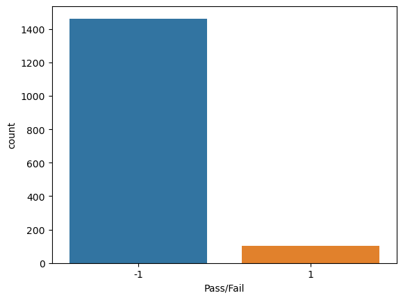

```python
sns.countplot(signal_df, x='Pass/Fail')
```

**Observations:**

- We can see target variable Pass/Fail has two types of values -1 and 1
- We can see high imbalance between the distribution of both values, where more than 1450 values are -1(Pass) and around 100 are 1(Fail). This might lead to majority prediction towards Pass. we will apply target balancing technique later.

```python
signal_df['Pass/Fail'].value_counts()
```

```
Pass/Fail
-1    1463
 1     104
Name: count, dtype: int64
```

Let us visualize Time column

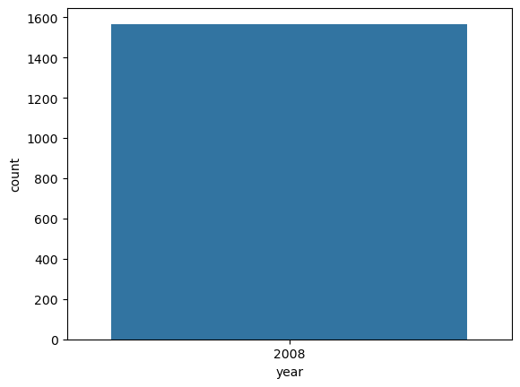

```python
signal_df_copy = signal_df.copy()
signal_df_copy['Time'] = pd.to_datetime(signal_df_copy['Time'])

signal_df_copy['year'] = signal_df_copy['Time'].dt.year
signal_df_copy['month'] = signal_df_copy['Time'].dt.month
signal_df_copy['day'] = signal_df_copy['Time'].dt.day
signal_df_copy['hour'] = signal_df_copy['Time'].dt.hour
signal_df_copy['minute'] = signal_df_copy['Time'].dt.minute

signal_df_copy.drop('Time',axis=1, inplace=True)
sns.countplot(signal_df_copy, x='year')
```

**Observation:**

- The data (signals/variables collected from sensors and or process measurement points) belongs to year 2008 only

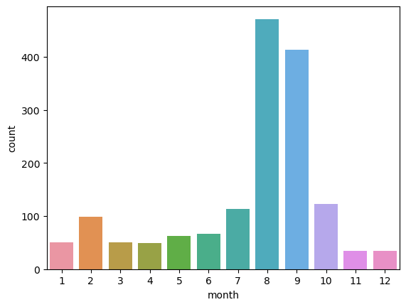

```python
sns.countplot(signal_df_copy, x='month')
```

**Observations:**

- The signals are collected for whole year i.e 12 months of 2008.
- Highest number of signals received are in year August followed by September and then October and then other months.

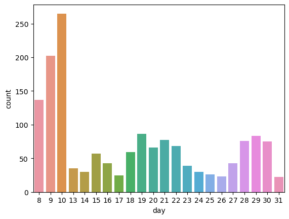

```python
sns.countplot(signal_df_copy, x='day')
```

**Observations:**

- All the signals have been collected on date ranging from 8 to 31, None of the data is collected in the 1st week of the month i.e from 1 to 7 days

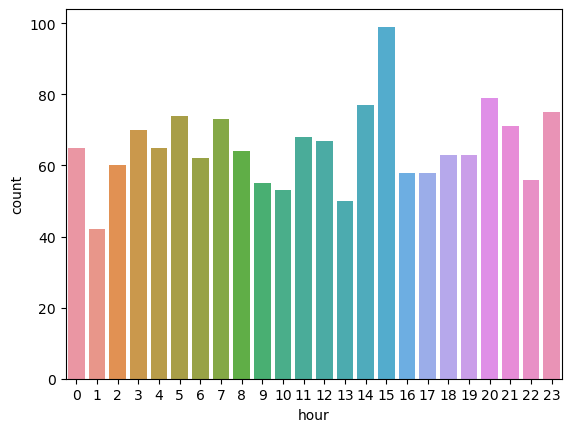

```python
sns.countplot(signal_df_copy, x='hour')
```

**Observations:**

- Signal is collected every hours in 24 hours.
- Highest number of signals collected is at 3 PM.

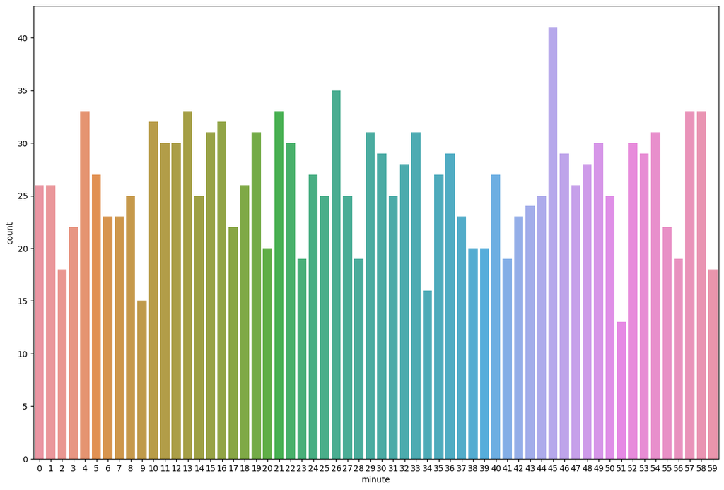

```python
plt.figure(figsize=(15,10))
sns.countplot(signal_df_copy, x='minute')
```

**Observations:**

- Highest signal collected is at 45 minutes and lowest data collected is at 51 minutes

```python
signal_df.describe().T
```

|  | count | mean | std | min | 25% | 50% | 75% | max |
| --- | --- | --- | --- | --- | --- | --- | --- | --- |
| 2 | 1567.0 | 2200.547318 | 29.380932 | 2060.6600 | 2181.09995 | 2200.9556 | 2218.05550 | 2315.2667 |
| 9 | 1567.0 | -0.000841 | 0.015107 | -0.0534 | -0.01080 | -0.0013 | 0.00840 | 0.0749 |
| 14 | 1567.0 | 9.005371 | 2.793916 | 2.2493 | 7.09675 | 8.9739 | 10.85870 | 19.5465 |
| 21 | 1567.0 | -5618.393610 | 626.421781 | -7150.2500 | -5932.62500 | -5523.2500 | -5356.62500 | 0.0000 |
| 22 | 1567.0 | 2699.378435 | 295.309778 | 0.0000 | 2578.12500 | 2664.0000 | 2840.62500 | 3656.2500 |
| ... | ... | ... | ... | ... | ... | ... | ... | ... |
| 569 | 1567.0 | 21.117674 | 9.280454 | 3.2504 | 15.46620 | 20.1824 | 23.03520 | 84.8024 |
| 571 | 1567.0 | 2.101836 | 0.275112 | 0.9802 | 1.98290 | 2.1186 | 2.29065 | 2.7395 |
| 575 | 1567.0 | 0.104729 | 0.067791 | 0.0230 | 0.07510 | 0.0895 | 0.11215 | 0.5502 |
| 587 | 1567.0 | 0.016475 | 0.008805 | 0.0032 | 0.01060 | 0.0148 | 0.02030 | 0.0799 |
| Pass/Fail | 1567.0 | -0.867262 | 0.498010 | -1.0000 | -1.00000 | -1.0000 | -1.00000 | 1.0000 |

65 rows × 8 columns

Let us do visualization for feature 2 and 22 as feature 2 has less variations in min and max but 22 have more variation as min is 0 and max is 3656.25

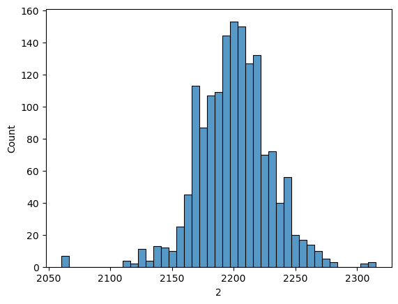

```python
sns.histplot(signal_df_copy, x='2')
```

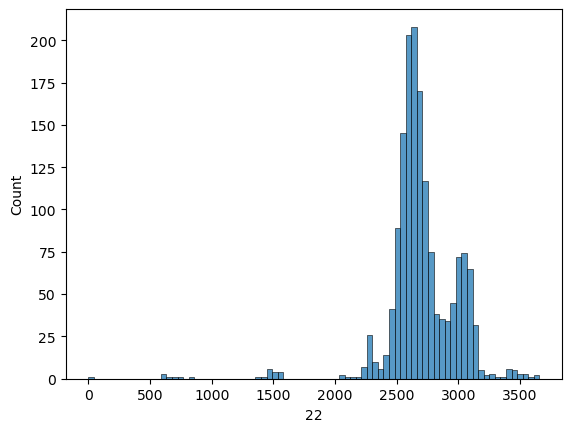

```python
sns.histplot(signal_df_copy, x='22')
```

**Observations:**

- values less than 2000 looks like outlier
- actual values ranging from 2000 to 3600 around.

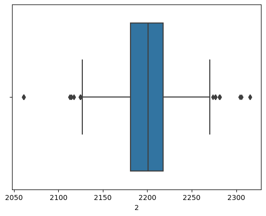

```python
sns.boxplot(signal_df, x='2')
```

#### B. Perform bivariate and multivariate analysis with appropriate detailed comments after each analysis. [3 Marks]

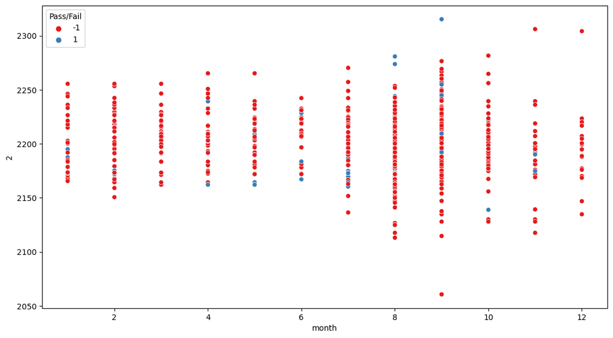

```python
plt.figure(figsize=(13,7))
sns.scatterplot(signal_df_copy, x='month', y='2', hue='Pass/Fail', palette='Set1') #-1 - Pass, 1 Fail
```

**Observations:**

- We can see monthwise signals captured for variable 2 distinguished by target variable Pass/Fail where -1 is for Pass, 1 is for Fail
- Most the of the collected signals of signal type 2 has Yield type i.e Pass/Fail Pass throughout year, here pass represented by red color and Fail by blue color.
- For month Aug and Sept, Fails are for the highest signals value of signal type 2.

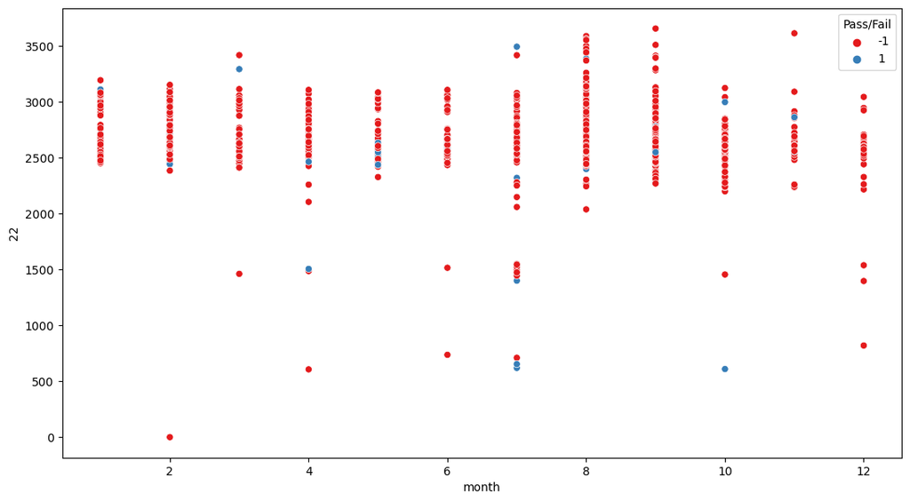

```python
plt.figure(figsize=(13,7))
sns.scatterplot(signal_df_copy, x='month', y='22', hue='Pass/Fail', palette='Set1') #-1 - Pass, 1 Fail
```

```python
#drop year value as it is constant 2008, it is not going to add value in modelling
signal_df_copy.drop('year', axis=1, inplace=True)
```

```python
signal_df_copy.head()
```

|  | 2 | 9 | 14 | 21 | 22 | 24 | 31 | 40 | 59 | 64 | ... | 562 | 569 | 571 | 575 | 587 | Pass/Fail | month | day | hour | minute |
| --- | --- | --- | --- | --- | --- | --- | --- | --- | --- | --- | --- | --- | --- | --- | --- | --- | --- | --- | --- | --- | --- |
| 0 | 2187.7333 | 0.0162 | 7.9558 | -5419.00 | 2916.50 | 751.00 | 3.5191 | 61.29 | -1.7264 | 21.7264 | ... | 262.729683 | 21.117674 | 2.1113 | 0.1026 | 0.016475 | -1 | 7 | 19 | 11 | 55 |
| 1 | 2230.4222 | -0.0005 | 10.1548 | -5441.50 | 2604.25 | -1640.25 | 3.4171 | 78.25 | 0.8073 | 19.1927 | ... | 262.729683 | 21.117674 | 2.4335 | 0.0772 | 0.020100 | -1 | 7 | 19 | 12 | 32 |
| 2 | 2186.4111 | 0.0041 | 9.5157 | -5447.75 | 2701.75 | -1916.50 | 3.5986 | 14.37 | 23.8245 | 16.1755 | ... | 267.064000 | 68.848900 | 2.0293 | 0.0640 | 0.048400 | 1 | 7 | 19 | 13 | 17 |
| 3 | 2199.0333 | -0.0124 | 9.6052 | -5468.25 | 2648.25 | -1657.25 | 3.3813 | 76.90 | 24.3791 | 15.6209 | ... | 268.228000 | 25.036300 | 2.0253 | 0.0525 | 0.014900 | -1 | 7 | 19 | 14 | 43 |
| 4 | 2233.3667 | -0.0031 | 10.5661 | -5476.25 | 2635.25 | 117.00 | 3.2728 | 76.39 | -12.2945 | 32.2945 | ... | 262.729683 | 21.117674 | 2.0275 | 0.0706 | 0.014900 | -1 | 7 | 19 | 15 | 22 |

5 rows × 69 columns

**Now Let us visualize HeatMap**

```python
corr = signal_df_copy.corr()
corr
```

|  | 2 | 9 | 14 | 21 | 22 | 24 | 31 | 40 | 59 | 64 | ... | 562 | 569 | 571 | 575 | 587 | Pass/Fail | month | day | hour | minute |
| --- | --- | --- | --- | --- | --- | --- | --- | --- | --- | --- | --- | --- | --- | --- | --- | --- | --- | --- | --- | --- | --- |
| 2 | 1.000000 | 0.016168 | 0.006476 | 0.044468 | -0.029830 | -0.021149 | -0.007405 | -0.014761 | 0.039710 | 0.007603 | ... | 0.013310 | 0.064282 | -0.015600 | -0.035041 | -0.029345 | -0.000957 | -0.038922 | -0.036763 | -0.001654 | -0.015614 |
| 9 | 0.016168 | 1.000000 | -0.004359 | -0.001024 | -0.002356 | 0.014420 | -0.001540 | 0.000777 | -0.026476 | -0.023801 | ... | 0.027376 | -0.037587 | 0.016960 | 0.036089 | 0.059301 | -0.031191 | 0.155016 | 0.113938 | 0.017900 | -0.012988 |
| 14 | 0.006476 | -0.004359 | 1.000000 | -0.034719 | -0.013903 | 0.030261 | 0.046208 | -0.016182 | -0.005247 | -0.006558 | ... | 0.015466 | 0.002705 | 0.022778 | 0.013565 | 0.044234 | -0.068975 | -0.078974 | -0.132537 | -0.005149 | -0.022517 |
| 21 | 0.044468 | -0.001024 | -0.034719 | 1.000000 | -0.725921 | -0.179501 | -0.598832 | -0.059722 | -0.026307 | 0.112512 | ... | 0.025136 | 0.029445 | -0.053169 | 0.020319 | 0.022317 | 0.107997 | 0.039405 | -0.003931 | 0.027227 | -0.004727 |
| 22 | -0.029830 | -0.002356 | -0.013903 | -0.725921 | 1.000000 | 0.119966 | 0.419245 | -0.011674 | 0.053719 | -0.098182 | ... | -0.066227 | -0.012544 | 0.033662 | 0.000640 | -0.046610 | -0.073380 | -0.052996 | 0.093747 | -0.028153 | -0.007568 |
| ... | ... | ... | ... | ... | ... | ... | ... | ... | ... | ... | ... | ... | ... | ... | ... | ... | ... | ... | ... | ... | ... |
| Pass/Fail | -0.000957 | -0.031191 | -0.068975 | 0.107997 | -0.073380 | -0.018297 | -0.049009 | -0.051763 | 0.155771 | 0.076551 | ... | -0.043051 | 0.045828 | -0.019353 | -0.052731 | 0.035391 | 1.000000 | -0.020689 | 0.000713 | 0.015963 | 0.010431 |
| month | -0.038922 | 0.155016 | -0.078974 | 0.039405 | -0.052996 | -0.056207 | -0.096959 | 0.042226 | -0.073482 | 0.002991 | ... | -0.041198 | 0.001718 | 0.131825 | 0.004594 | 0.005449 | -0.020689 | 1.000000 | 0.407196 | 0.020851 | -0.009937 |
| day | -0.036763 | 0.113938 | -0.132537 | -0.003931 | 0.093747 | 0.014776 | 0.010326 | -0.082353 | -0.030345 | -0.065110 | ... | -0.048215 | 0.044860 | 0.075599 | -0.013716 | -0.001288 | 0.000713 | 0.407196 | 1.000000 | -0.013218 | 0.011992 |
| hour | -0.001654 | 0.017900 | -0.005149 | 0.027227 | -0.028153 | -0.033220 | -0.017507 | -0.032150 | 0.001136 | 0.049205 | ... | -0.002284 | 0.028834 | 0.013755 | -0.015607 | 0.033205 | 0.015963 | 0.020851 | -0.013218 | 1.000000 | -0.032017 |
| minute | -0.015614 | -0.012988 | -0.022517 | -0.004727 | -0.007568 | -0.005252 | -0.021825 | 0.002122 | -0.010767 | -0.034746 | ... | -0.022548 | 0.017574 | -0.051937 | -0.028252 | 0.029273 | 0.010431 | -0.009937 | 0.011992 | -0.032017 | 1.000000 |

69 rows × 69 columns

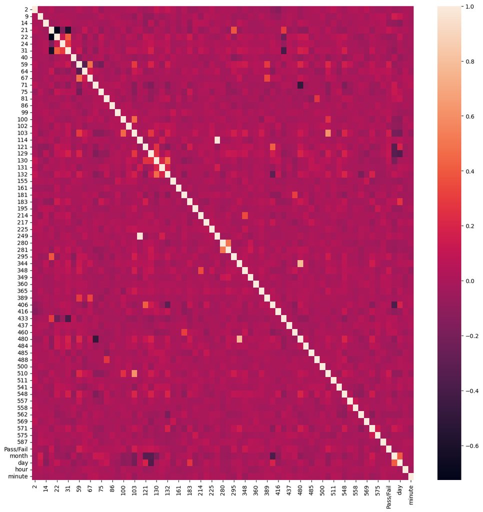

```python
plt.figure(figsize=(15,15))
sns.heatmap(corr)
```

**Observations:**

- In the above heatmap, we see that light color is representing strong positive correlation and dark color is strong negative correlation.
- Very few places we see either dark or light color representation in the heatmap, it means we don't have too many column with string positive or negative correlation.
- Also, we have already done high correlation treatment on the dataset. that's why we can see less correated features.

#### 4. Data pre-processing: [10 Marks]

#### A. Segregate predictors vs target attributes. [2 Marks]

```python
#Segregating all variables except Pass/Fail as predictors
X = signal_df_copy.drop('Pass/Fail', axis=1)
#Segregating Pass/Fail variable as target variable
Y = signal_df_copy['Pass/Fail']
```

#### B. Check for target balancing and fix it if found imbalanced. [3 Marks]

#### C. Perform train-test split and standardise the data or vice versa if required. [3 Marks]

```python
print(signal_df_copy['Pass/Fail'].value_counts())
print(signal_df_copy['Pass/Fail'].value_counts(normalize=True))
```

```
Pass/Fail
-1    1463
 1     104
Name: count, dtype: int64
Pass/Fail
-1    0.933631
 1    0.066369
Name: proportion, dtype: float64
```

```python
print(Y.value_counts())
print(Y.value_counts(normalize=True))
```

```
Pass/Fail
-1    1463
 1     104
Name: count, dtype: int64
Pass/Fail
-1    0.933631
 1    0.066369
Name: proportion, dtype: float64
```

We see that 1463 (93.3%) values represent Pass class whereas, 104 (6.6%) values represents Fail class which is highly imbalanced.  
We will do upsampling for minority class i.e 1 Fail using SMOTE (Synthetic Minority Over Sampling Technique) from imblearn library.  
**Since, SMOTE should only be applied to the training data only, not to the entire dataset (including both training and testing data) to avoid data leakage, realistic evaluation and maintain class distribution on test. So, We will first do the train test split, SMOTE and then standardization.**

```python
#train test split
X_train, X_test, Y_train, Y_test = train_test_split(X, Y, test_size=0.25, stratify=Y, random_state=1)
```

```python
print("Before Synthetic Over Sampling:")
print("X_train shape:", X_train.shape)
print("Y_train shape:", Y_train.shape)
print("Target Distribution:",Y_train.value_counts())
```

```
Before Synthetic Over Sampling:
X_train shape: (1175, 68)
Y_train shape: (1175,)
Target Distribution: Pass/Fail
-1    1097
 1      78
Name: count, dtype: int64
```

```python
#over sampling
from imblearn.over_sampling import SMOTE
sm=SMOTE()
X_train_sm, Y_train_sm = sm.fit_resample(X_train, Y_train)
print("After Synthetic Over Sampling:")
print("X_train shape:", X_train_sm.shape)
print("Y_train shape:", Y_train_sm.shape)
print("Target Distribution:",Y_train_sm.value_counts())
```

```
After Synthetic Over Sampling:
X_train shape: (2194, 68)
Y_train shape: (2194,)
Target Distribution: Pass/Fail
-1    1097
 1    1097
Name: count, dtype: int64
```

We can see the target variable is balanced equally now and the shape is increased to 2194 rows.

```python
#standardizing the data
from sklearn.preprocessing import StandardScaler
scaler = StandardScaler()
X_train_scaled = pd.DataFrame(scaler.fit_transform(X_train_sm), columns=X_train.columns)

X_test_scaled = pd.DataFrame(scaler.fit_transform(X_test), columns=X_test.columns)
```

```python
X_train_scaled
```

|  | 2 | 9 | 14 | 21 | 22 | 24 | 31 | 40 | 59 | 64 | ... | 558 | 562 | 569 | 571 | 575 | 587 | month | day | hour | minute |
| --- | --- | --- | --- | --- | --- | --- | --- | --- | --- | --- | --- | --- | --- | --- | --- | --- | --- | --- | --- | --- | --- |
| 0 | 1.209027 | -2.282790 | -1.069762 | -0.282160 | -0.049662 | -0.511405 | -0.265503 | 0.486912 | -0.488824 | -0.361301 | ... | -0.264646 | 0.338014 | -0.670857 | -0.568990 | -1.017426 | -0.601533 | 0.391417 | 1.545122 | -0.863578 | -0.875529 |
| 1 | 0.571734 | 1.388221 | -0.407225 | -1.086921 | 1.152863 | 0.725769 | 2.250929 | 0.603969 | -0.260664 | -0.757070 | ... | 0.095568 | 0.107849 | -0.096971 | 0.953710 | 0.316749 | -0.366390 | 0.391417 | 0.680179 | -1.179702 | 0.588490 |
| 2 | 1.220273 | -1.960386 | -0.540882 | 0.075706 | -0.381033 | 0.161487 | -0.309669 | 0.702632 | -0.605831 | -0.158341 | ... | -0.449461 | -1.404730 | 1.144851 | -0.241872 | -0.375648 | -0.267383 | -0.476026 | -1.049705 | -0.231330 | -1.344015 |
| 3 | -0.597897 | 1.205037 | 0.410775 | 0.597035 | -0.183072 | 0.315625 | -0.873574 | 0.629053 | -0.433022 | -0.458096 | ... | 0.290978 | 0.338014 | -0.670857 | 0.286434 | 0.416179 | 1.291983 | 1.258859 | -0.184763 | -1.179702 | 0.998416 |
| 4 | 0.271413 | -0.238454 | 1.772077 | 0.003024 | -0.103764 | 3.601359 | -0.339392 | 0.621946 | -0.061427 | -1.102666 | ... | -0.218736 | 0.338014 | -0.670857 | -1.643860 | -0.234638 | 0.165774 | 0.825138 | -0.473077 | -1.495826 | 1.701145 |
| ... | ... | ... | ... | ... | ... | ... | ... | ... | ... | ... | ... | ... | ... | ... | ... | ... | ... | ... | ... | ... | ... |
| 2189 | -0.282607 | -0.409048 | -1.073777 | 0.160269 | 0.081359 | -0.360813 | -0.338279 | -0.656565 | 0.888330 | -1.105573 | ... | 3.078752 | 0.314187 | -1.065686 | -0.025083 | -0.584540 | 0.255513 | -0.042305 | 1.545122 | -1.179702 | 1.174098 |
| 2190 | -0.623087 | 0.554745 | 0.120382 | 0.302720 | 0.458764 | 0.305764 | -0.371850 | 0.328515 | 1.066493 | 0.490329 | ... | 0.007203 | 0.295223 | 0.023450 | 0.866572 | 0.074487 | 0.648810 | 0.391417 | 0.103551 | -1.653888 | -0.114239 |
| 2191 | 0.915538 | -0.321667 | -0.881163 | 4.678127 | -5.003212 | 0.208014 | -0.307781 | 0.420859 | 0.903440 | 0.773161 | ... | -0.207879 | -1.739664 | 0.494000 | 1.263534 | 0.388747 | 0.658098 | 0.391417 | -0.761391 | 0.242856 | 1.525463 |
| 2192 | -1.363486 | -0.259600 | -0.660855 | 0.085531 | -0.384937 | -1.533098 | -0.652038 | 0.685132 | -0.674640 | -0.038985 | ... | -0.202689 | 0.751091 | -0.724873 | -0.267513 | -0.042575 | 0.297283 | -1.343469 | -1.049705 | 0.875105 | -0.114239 |
| 2193 | -1.367674 | -1.126821 | -0.409298 | 3.894126 | -3.612865 | 0.142949 | -0.348161 | -0.608255 | 0.623298 | 1.259098 | ... | -0.556405 | 0.157452 | -0.484444 | 0.025632 | -0.416882 | 0.560124 | -0.042305 | 1.400965 | 0.242856 | -0.289921 |

2194 rows × 68 columns

```python
X_test_scaled
```

|  | 2 | 9 | 14 | 21 | 22 | 24 | 31 | 40 | 59 | 64 | ... | 558 | 562 | 569 | 571 | 575 | 587 | month | day | hour | minute |
| --- | --- | --- | --- | --- | --- | --- | --- | --- | --- | --- | --- | --- | --- | --- | --- | --- | --- | --- | --- | --- | --- |
| 0 | -1.087583 | 0.075609 | -1.047485 | -0.077253 | -0.502342 | -0.821428 | -0.766500 | -0.104955 | 0.030713 | -0.799603 | ... | -0.360489 | 0.242545 | -0.652611 | -3.445128 | -0.810939 | -0.751420 | -2.216897 | -0.908910 | -0.726861 | 0.359248 |
| 1 | -0.107561 | 0.716678 | 1.381786 | 0.345194 | -0.381218 | 0.235251 | -0.351193 | 0.494412 | -0.648514 | 0.510568 | ... | -0.351806 | 1.392349 | 0.368660 | -0.991481 | 3.491493 | 2.224564 | 1.753060 | -0.908910 | -1.778815 | 1.662087 |
| 2 | -0.225401 | 0.062254 | -0.314969 | 0.113364 | 0.724502 | 0.197963 | -0.424672 | 0.448108 | -0.611451 | 0.439076 | ... | 0.031305 | 0.581736 | -0.176064 | 1.489316 | -0.349060 | -0.345105 | 0.562073 | 0.141714 | -0.576581 | -1.476572 |
| 3 | -0.765009 | 2.372773 | -0.278956 | 0.510481 | -0.215130 | -0.445058 | -0.477130 | 0.557254 | -0.293602 | -0.174027 | ... | -0.536308 | 0.242545 | -0.652611 | -2.333346 | -1.078259 | -0.531790 | 0.165077 | -0.908910 | 0.625652 | -0.173732 |
| 4 | 0.657016 | 1.544726 | -1.593786 | 0.374388 | -0.136216 | -0.032473 | -0.582424 | 0.310138 | 1.969128 | -0.252549 | ... | -0.320333 | 0.567282 | 1.688716 | 1.736456 | -0.045359 | -0.345105 | -1.025910 | -1.171566 | -1.027419 | -1.062032 |
| ... | ... | ... | ... | ... | ... | ... | ... | ... | ... | ... | ... | ... | ... | ... | ... | ... | ... | ... | ... | ... | ... |
| 387 | 0.106299 | 0.442888 | -1.716593 | 0.240441 | 0.117962 | -1.020388 | -0.686014 | 0.391880 | 1.202530 | 1.226152 | ... | -0.500493 | 0.005401 | 0.056964 | -2.042348 | -0.530964 | -0.839272 | 0.165077 | -0.252270 | -1.027419 | -0.943592 |
| 388 | 4.033538 | 0.543055 | -0.747993 | 1.086623 | 0.690550 | -0.620858 | -0.429785 | 0.459920 | 0.296556 | -1.312391 | ... | 0.502325 | 0.242545 | -0.652611 | 0.603790 | -0.239918 | -1.344420 | 0.562073 | 0.273042 | 1.377048 | -1.180472 |
| 389 | -0.380141 | -0.825894 | -0.543245 | 0.217258 | 0.138149 | -0.255845 | -0.402704 | -0.202993 | 2.959139 | -2.162194 | ... | -0.526540 | 0.005401 | 0.056964 | 0.352821 | -0.480348 | 0.006303 | -0.231918 | 1.323665 | 1.226769 | -0.292172 |
| 390 | -0.373792 | -0.652271 | -1.570997 | 0.285090 | -0.316985 | -0.358320 | -0.460843 | 0.570957 | -0.110885 | -0.526472 | ... | -0.426692 | 0.242545 | -0.652611 | -0.417142 | -0.594235 | -0.246271 | -1.819901 | -0.908910 | 1.226769 | 0.359248 |
| 391 | 0.324523 | -0.438582 | 0.173622 | 0.589046 | -0.559234 | -0.027644 | -0.108788 | 0.534575 | -1.057877 | 1.300194 | ... | -0.129320 | 0.242545 | -0.652611 | -0.156775 | -0.163992 | 0.434581 | -1.025910 | -0.908910 | 0.926210 | 1.010667 |

392 rows × 68 columns

#### D. Check if the train and test data have similar statistical characteristics when compared with original data. [2 Marks]

```python
signal_df_original_describe = pd.read_csv('signal-data.csv').describe().T #Here considering original data means raw data before preprocessing
signal_df_original_describe
```

|  | count | mean | std | min | 25% | 50% | 75% | max |
| --- | --- | --- | --- | --- | --- | --- | --- | --- |
| 0 | 1561.0 | 3014.452896 | 73.621787 | 2743.2400 | 2966.260000 | 3011.4900 | 3056.6500 | 3356.3500 |
| 1 | 1560.0 | 2495.850231 | 80.407705 | 2158.7500 | 2452.247500 | 2499.4050 | 2538.8225 | 2846.4400 |
| 2 | 1553.0 | 2200.547318 | 29.513152 | 2060.6600 | 2181.044400 | 2201.0667 | 2218.0555 | 2315.2667 |
| 3 | 1553.0 | 1396.376627 | 441.691640 | 0.0000 | 1081.875800 | 1285.2144 | 1591.2235 | 3715.0417 |
| 4 | 1553.0 | 4.197013 | 56.355540 | 0.6815 | 1.017700 | 1.3168 | 1.5257 | 1114.5366 |
| ... | ... | ... | ... | ... | ... | ... | ... | ... |
| 586 | 1566.0 | 0.021458 | 0.012358 | -0.0169 | 0.013425 | 0.0205 | 0.0276 | 0.1028 |
| 587 | 1566.0 | 0.016475 | 0.008808 | 0.0032 | 0.010600 | 0.0148 | 0.0203 | 0.0799 |
| 588 | 1566.0 | 0.005283 | 0.002867 | 0.0010 | 0.003300 | 0.0046 | 0.0064 | 0.0286 |
| 589 | 1566.0 | 99.670066 | 93.891919 | 0.0000 | 44.368600 | 71.9005 | 114.7497 | 737.3048 |
| Pass/Fail | 1567.0 | -0.867262 | 0.498010 | -1.0000 | -1.000000 | -1.0000 | -1.0000 | 1.0000 |

591 rows × 8 columns

```python
X_train_describe = X_train.describe().T
X_train_describe
```

[output not shown]

68 rows × 8 columns

```python
Y_train_describe = Y_train.describe().T
Y_train_describe
```

[output not shown]

```python
X_test_describe = X_test.describe().T
X_test_describe
```

[output not shown]

68 rows × 8 columns

```python
Y_test_describe = Y_test.describe().T
Y_test_describe
```

```
count    392.000000
mean      -0.867347
std        0.498340
min       -1.000000
25%       -1.000000
50%       -1.000000
75%       -1.000000
max        1.000000
Name: Pass/Fail, dtype: float64
```

**Comparision of Original data(data before preprocessing) with train and test data:**

```python
pd.concat([signal_df_original_describe.loc['2'], X_train_describe.loc['2'], X_test_describe.loc['2']], axis=1, keys=['Original "2"','X_train "2"', 'X_test "2"']).T
```

|  | count | mean | std | min | 25% | 50% | 75% | max |
| --- | --- | --- | --- | --- | --- | --- | --- | --- |
| Original "2" | 1553.0 | 2200.547318 | 29.513152 | 2060.6600 | 2181.0444 | 2201.066700 | 2218.055500 | 2315.2667 |
| X_train "2" | 1175.0 | 2199.958553 | 29.803329 | 2060.6600 | 2180.7000 | 2200.547318 | 2218.055500 | 2315.2667 |
| X_test "2" | 392.0 | 2202.312109 | 28.039637 | 2113.0778 | 2184.7639 | 2201.066700 | 2218.591675 | 2315.2667 |

- Looking at the above comparision of original, training and test dataset, we find that counts of rows is changed.
- In Original dataset column 2, count is 1553, wich was including null values as well, that's why the count is 1553 and not 1567.
- if we compare the mean, std, min, 25%, 50%, 75%, max of variable 2 for all the datasets, there absolute values are almost equal or near by. that is due to the data preprocessing we did like null value imputation with mean. there is slight difference in std deviation 29.5, 29.8 and 28.03 in original, train and test. These differences are obvious as the data before preprocessing and after preprocessing.

```python
pd.concat([signal_df_original_describe.loc['Pass/Fail'], Y_train_describe, Y_test_describe], axis=1, keys=['Original "Pass/Fail"','Y_train "Pass/Fail"', 'Y_test "Pass/Fail"']).T
```

|  | count | mean | std | min | 25% | 50% | 75% | max |
| --- | --- | --- | --- | --- | --- | --- | --- | --- |
| Original "Pass/Fail" | 1567.0 | -0.867262 | 0.498010 | -1.0 | -1.0 | -1.0 | -1.0 | 1.0 |
| Y_train "Pass/Fail" | 1175.0 | -0.867234 | 0.498113 | -1.0 | -1.0 | -1.0 | -1.0 | 1.0 |
| Y_test "Pass/Fail" | 392.0 | -0.867347 | 0.498340 | -1.0 | -1.0 | -1.0 | -1.0 | 1.0 |

- For target variable of original, train and test data, we cna see the mean and standard diveation changes in fraction but almost nearby.

**Let us now do comparision of original data considering data after preprocessing and train and test data before oversampling.**  
**We will use same train and test data as above for comparision here.**

```python
#Original Data:
signal_df_copy_describe = signal_df_copy.describe().T #Here considering original data means data after preprocessing
signal_df_copy_describe
```

|  | count | mean | std | min | 25% | 50% | 75% | max |
| --- | --- | --- | --- | --- | --- | --- | --- | --- |
| 2 | 1567.0 | 2200.547318 | 29.380932 | 2060.6600 | 2181.09995 | 2200.9556 | 2218.0555 | 2315.2667 |
| 9 | 1567.0 | -0.000841 | 0.015107 | -0.0534 | -0.01080 | -0.0013 | 0.0084 | 0.0749 |
| 14 | 1567.0 | 9.005371 | 2.793916 | 2.2493 | 7.09675 | 8.9739 | 10.8587 | 19.5465 |
| 21 | 1567.0 | -5618.393610 | 626.421781 | -7150.2500 | -5932.62500 | -5523.2500 | -5356.6250 | 0.0000 |
| 22 | 1567.0 | 2699.378435 | 295.309778 | 0.0000 | 2578.12500 | 2664.0000 | 2840.6250 | 3656.2500 |
| ... | ... | ... | ... | ... | ... | ... | ... | ... |
| Pass/Fail | 1567.0 | -0.867262 | 0.498010 | -1.0000 | -1.00000 | -1.0000 | -1.0000 | 1.0000 |
| month | 1567.0 | 7.409700 | 2.554511 | 1.0000 | 7.00000 | 8.0000 | 9.0000 | 12.0000 |
| day | 1567.0 | 17.248883 | 7.613716 | 8.0000 | 10.00000 | 17.0000 | 23.0000 | 31.0000 |
| hour | 1567.0 | 11.780472 | 6.880780 | 0.0000 | 6.00000 | 12.0000 | 18.0000 | 23.0000 |
| minute | 1567.0 | 29.470325 | 17.230137 | 0.0000 | 15.00000 | 29.0000 | 45.0000 | 59.0000 |

69 rows × 8 columns

**Comparision of Original data(data after preprocessing) with train data(before oversampling) and test data:**

```python
pd.concat([signal_df_copy_describe.loc['2'], X_train_describe.loc['2'], X_test_describe.loc['2']], axis=1, keys=['Original "2"','X_train "2"', 'X_test "2"']).T
```

|  | count | mean | std | min | 25% | 50% | 75% | max |
| --- | --- | --- | --- | --- | --- | --- | --- | --- |
| Original "2" | 1567.0 | 2200.547318 | 29.380932 | 2060.6600 | 2181.09995 | 2200.955600 | 2218.055500 | 2315.2667 |
| X_train "2" | 1175.0 | 2199.958553 | 29.803329 | 2060.6600 | 2180.70000 | 2200.547318 | 2218.055500 | 2315.2667 |
| X_test "2" | 392.0 | 2202.312109 | 28.039637 | 2113.0778 | 2184.76390 | 2201.066700 | 2218.591675 | 2315.2667 |

- Looking at the count of original, it is 1567 now which in previous case was just 1553, due to null vlaues.
- In train we have 75% of Original data and test has 25% of original data.
- Looking at the mean, standard deviation, minimum, 25%, 50%, 75% has slight negligible differences and that may be due to diffent set and count of data present in original, train and test dataset. Exact differences we can clear see in this comparision table.

```python
pd.concat([signal_df_copy_describe.loc['Pass/Fail'], Y_train_describe, Y_test_describe], axis=1, keys=['Original "Pass/Fail"','Y_train "Pass/Fail"', 'Y_test "Pass/Fail"']).T
```

|  | count | mean | std | min | 25% | 50% | 75% | max |
| --- | --- | --- | --- | --- | --- | --- | --- | --- |
| Original "Pass/Fail" | 1567.0 | -0.867262 | 0.498010 | -1.0 | -1.0 | -1.0 | -1.0 | 1.0 |
| Y_train "Pass/Fail" | 1175.0 | -0.867234 | 0.498113 | -1.0 | -1.0 | -1.0 | -1.0 | 1.0 |
| Y_test "Pass/Fail" | 392.0 | -0.867347 | 0.498340 | -1.0 | -1.0 | -1.0 | -1.0 | 1.0 |

- Target variable describe is almost same, just the counts are changing based on train test split as 75:25%
- mean and standard deviation has slight differences in fraction. rest all (25%, 50%, 75%, max )are same

**Let us now consider original data as data after preprocessing i.e describe having in signal_df_copy_describe variable, and consider training data as data after balancing target variable of X, test data target is not balanced to avoid noise and error in test data. So we will use X_test_describe and Y_test_describe here for comparision**

```python
X_train_sm_describe = X_train_sm.describe().T
X_train_sm_describe
```

|  | count | mean | std | min | 25% | 50% | 75% | max |
| --- | --- | --- | --- | --- | --- | --- | --- | --- |
| 2 | 2194.0 | 2198.504510 | 26.681246 | 2060.6600 | 2179.743758 | 2197.912331 | 2215.104523 | 2315.2667 |
| 9 | 2194.0 | -0.001346 | 0.013651 | -0.0534 | -0.009900 | -0.001486 | 0.007360 | 0.0749 |
| 14 | 2194.0 | 8.834709 | 2.559384 | 2.2493 | 7.016725 | 8.871526 | 10.525846 | 18.8626 |
| 21 | 2194.0 | -5469.339811 | 856.660792 | -7150.2500 | -5747.585111 | -5488.502492 | -5327.562500 | -1263.5000 |
| 22 | 2194.0 | 2647.694966 | 406.736898 | 606.5000 | 2578.625000 | 2659.884210 | 2794.123362 | 3656.2500 |
| ... | ... | ... | ... | ... | ... | ... | ... | ... |
| 587 | 2194.0 | 0.017061 | 0.008082 | 0.0042 | 0.011466 | 0.015658 | 0.021096 | 0.0799 |
| month | 2194.0 | 7.097539 | 2.306153 | 1.0000 | 6.000000 | 8.000000 | 9.000000 | 12.0000 |
| day | 2194.0 | 17.281677 | 6.938461 | 8.0000 | 10.000000 | 17.000000 | 22.000000 | 31.0000 |
| hour | 2194.0 | 11.463537 | 6.328072 | 0.0000 | 6.000000 | 12.000000 | 17.000000 | 23.0000 |
| minute | 2194.0 | 29.950775 | 17.080169 | 0.0000 | 15.000000 | 30.000000 | 45.000000 | 59.0000 |

68 rows × 8 columns

```python
Y_train_sm_describe = Y_train_sm.describe().T
Y_train_sm_describe
```

```
count    2194.000000
mean        0.000000
std         1.000228
min        -1.000000
25%        -1.000000
50%         0.000000
75%         1.000000
max         1.000000
Name: Pass/Fail, dtype: float64
```

**Comparision of Original data(data after preprocessing) with train data (after target balancing) and test data:**

```python
pd.concat([signal_df_copy_describe.loc['2'], X_train_sm_describe.loc['2'], X_test_describe.loc['2']], axis=1, keys=['Original "2"','X_train "2"', 'X_test "2"']).T
```

|  | count | mean | std | min | 25% | 50% | 75% | max |
| --- | --- | --- | --- | --- | --- | --- | --- | --- |
| Original "2" | 1567.0 | 2200.547318 | 29.380932 | 2060.6600 | 2181.099950 | 2200.955600 | 2218.055500 | 2315.2667 |
| X_train "2" | 2194.0 | 2198.504510 | 26.681246 | 2060.6600 | 2179.743758 | 2197.912331 | 2215.104523 | 2315.2667 |
| X_test "2" | 392.0 | 2202.312109 | 28.039637 | 2113.0778 | 2184.763900 | 2201.066700 | 2218.591675 | 2315.2667 |

```python
pd.concat([signal_df_copy_describe.loc['Pass/Fail'], Y_train_sm_describe, Y_test_describe], axis=1, keys=['Original "Pass/Fail"','Y_train "Pass/Fail"', 'Y_test "Pass/Fail"']).T
```

|  | count | mean | std | min | 25% | 50% | 75% | max |
| --- | --- | --- | --- | --- | --- | --- | --- | --- |
| Original "Pass/Fail" | 1567.0 | -0.867262 | 0.498010 | -1.0 | -1.0 | -1.0 | -1.0 | 1.0 |
| Y_train "Pass/Fail" | 2194.0 | 0.000000 | 1.000228 | -1.0 | -1.0 | 0.0 | 1.0 | 1.0 |
| Y_test "Pass/Fail" | 392.0 | -0.867347 | 0.498340 | -1.0 | -1.0 | -1.0 | -1.0 | 1.0 |

- Mean is changedfor Y_train to be 0 while others have -0.8, standard deviation is also different from original and test data, that is due to the target balancing we have done for Y_train.

**Note:**

- X_train_scaled - oversampled and standardized
- Y_train_sm - oversampled
- X_test_scaled - standardized
- Y_test - normal

**We will be using this data for models training and testing. So to avoid this confustion further, Let us do assignment as as below:**

```python
X_train = X_train_scaled
Y_train = Y_train_sm
X_test = X_test_scaled
Y_test = Y_test
```

```python
X_train
```

|  | 2 | 9 | 14 | 21 | 22 | 24 | 31 | 40 | 59 | 64 | ... | 558 | 562 | 569 | 571 | 575 | 587 | month | day | hour | minute |
| --- | --- | --- | --- | --- | --- | --- | --- | --- | --- | --- | --- | --- | --- | --- | --- | --- | --- | --- | --- | --- | --- |
| 0 | 1.209027 | -2.282790 | -1.069762 | -0.282160 | -0.049662 | -0.511405 | -0.265503 | 0.486912 | -0.488824 | -0.361301 | ... | -0.264646 | 0.338014 | -0.670857 | -0.568990 | -1.017426 | -0.601533 | 0.391417 | 1.545122 | -0.863578 | -0.875529 |
| 1 | 0.571734 | 1.388221 | -0.407225 | -1.086921 | 1.152863 | 0.725769 | 2.250929 | 0.603969 | -0.260664 | -0.757070 | ... | 0.095568 | 0.107849 | -0.096971 | 0.953710 | 0.316749 | -0.366390 | 0.391417 | 0.680179 | -1.179702 | 0.588490 |
| 2 | 1.220273 | -1.960386 | -0.540882 | 0.075706 | -0.381033 | 0.161487 | -0.309669 | 0.702632 | -0.605831 | -0.158341 | ... | -0.449461 | -1.404730 | 1.144851 | -0.241872 | -0.375648 | -0.267383 | -0.476026 | -1.049705 | -0.231330 | -1.344015 |
| 3 | -0.597897 | 1.205037 | 0.410775 | 0.597035 | -0.183072 | 0.315625 | -0.873574 | 0.629053 | -0.433022 | -0.458096 | ... | 0.290978 | 0.338014 | -0.670857 | 0.286434 | 0.416179 | 1.291983 | 1.258859 | -0.184763 | -1.179702 | 0.998416 |
| 4 | 0.271413 | -0.238454 | 1.772077 | 0.003024 | -0.103764 | 3.601359 | -0.339392 | 0.621946 | -0.061427 | -1.102666 | ... | -0.218736 | 0.338014 | -0.670857 | -1.643860 | -0.234638 | 0.165774 | 0.825138 | -0.473077 | -1.495826 | 1.701145 |
| ... | ... | ... | ... | ... | ... | ... | ... | ... | ... | ... | ... | ... | ... | ... | ... | ... | ... | ... | ... | ... | ... |
| 2189 | -0.282607 | -0.409048 | -1.073777 | 0.160269 | 0.081359 | -0.360813 | -0.338279 | -0.656565 | 0.888330 | -1.105573 | ... | 3.078752 | 0.314187 | -1.065686 | -0.025083 | -0.584540 | 0.255513 | -0.042305 | 1.545122 | -1.179702 | 1.174098 |
| 2190 | -0.623087 | 0.554745 | 0.120382 | 0.302720 | 0.458764 | 0.305764 | -0.371850 | 0.328515 | 1.066493 | 0.490329 | ... | 0.007203 | 0.295223 | 0.023450 | 0.866572 | 0.074487 | 0.648810 | 0.391417 | 0.103551 | -1.653888 | -0.114239 |
| 2191 | 0.915538 | -0.321667 | -0.881163 | 4.678127 | -5.003212 | 0.208014 | -0.307781 | 0.420859 | 0.903440 | 0.773161 | ... | -0.207879 | -1.739664 | 0.494000 | 1.263534 | 0.388747 | 0.658098 | 0.391417 | -0.761391 | 0.242856 | 1.525463 |
| 2192 | -1.363486 | -0.259600 | -0.660855 | 0.085531 | -0.384937 | -1.533098 | -0.652038 | 0.685132 | -0.674640 | -0.038985 | ... | -0.202689 | 0.751091 | -0.724873 | -0.267513 | -0.042575 | 0.297283 | -1.343469 | -1.049705 | 0.875105 | -0.114239 |
| 2193 | -1.367674 | -1.126821 | -0.409298 | 3.894126 | -3.612865 | 0.142949 | -0.348161 | -0.608255 | 0.623298 | 1.259098 | ... | -0.556405 | 0.157452 | -0.484444 | 0.025632 | -0.416882 | 0.560124 | -0.042305 | 1.400965 | 0.242856 | -0.289921 |

2194 rows × 68 columns

```python
Y_train
```

```
0      -1
1      -1
2      -1
3      -1
4      -1
       ..
2189    1
2190    1
2191    1
2192    1
2193    1
Name: Pass/Fail, Length: 2194, dtype: int64
```

```python
X_test
```

|  | 2 | 9 | 14 | 21 | 22 | 24 | 31 | 40 | 59 | 64 | ... | 558 | 562 | 569 | 571 | 575 | 587 | month | day | hour | minute |
| --- | --- | --- | --- | --- | --- | --- | --- | --- | --- | --- | --- | --- | --- | --- | --- | --- | --- | --- | --- | --- | --- |
| 0 | -1.087583 | 0.075609 | -1.047485 | -0.077253 | -0.502342 | -0.821428 | -0.766500 | -0.104955 | 0.030713 | -0.799603 | ... | -0.360489 | 0.242545 | -0.652611 | -3.445128 | -0.810939 | -0.751420 | -2.216897 | -0.908910 | -0.726861 | 0.359248 |
| 1 | -0.107561 | 0.716678 | 1.381786 | 0.345194 | -0.381218 | 0.235251 | -0.351193 | 0.494412 | -0.648514 | 0.510568 | ... | -0.351806 | 1.392349 | 0.368660 | -0.991481 | 3.491493 | 2.224564 | 1.753060 | -0.908910 | -1.778815 | 1.662087 |
| 2 | -0.225401 | 0.062254 | -0.314969 | 0.113364 | 0.724502 | 0.197963 | -0.424672 | 0.448108 | -0.611451 | 0.439076 | ... | 0.031305 | 0.581736 | -0.176064 | 1.489316 | -0.349060 | -0.345105 | 0.562073 | 0.141714 | -0.576581 | -1.476572 |
| 3 | -0.765009 | 2.372773 | -0.278956 | 0.510481 | -0.215130 | -0.445058 | -0.477130 | 0.557254 | -0.293602 | -0.174027 | ... | -0.536308 | 0.242545 | -0.652611 | -2.333346 | -1.078259 | -0.531790 | 0.165077 | -0.908910 | 0.625652 | -0.173732 |
| 4 | 0.657016 | 1.544726 | -1.593786 | 0.374388 | -0.136216 | -0.032473 | -0.582424 | 0.310138 | 1.969128 | -0.252549 | ... | -0.320333 | 0.567282 | 1.688716 | 1.736456 | -0.045359 | -0.345105 | -1.025910 | -1.171566 | -1.027419 | -1.062032 |
| ... | ... | ... | ... | ... | ... | ... | ... | ... | ... | ... | ... | ... | ... | ... | ... | ... | ... | ... | ... | ... | ... |
| 387 | 0.106299 | 0.442888 | -1.716593 | 0.240441 | 0.117962 | -1.020388 | -0.686014 | 0.391880 | 1.202530 | 1.226152 | ... | -0.500493 | 0.005401 | 0.056964 | -2.042348 | -0.530964 | -0.839272 | 0.165077 | -0.252270 | -1.027419 | -0.943592 |
| 388 | 4.033538 | 0.543055 | -0.747993 | 1.086623 | 0.690550 | -0.620858 | -0.429785 | 0.459920 | 0.296556 | -1.312391 | ... | 0.502325 | 0.242545 | -0.652611 | 0.603790 | -0.239918 | -1.344420 | 0.562073 | 0.273042 | 1.377048 | -1.180472 |
| 389 | -0.380141 | -0.825894 | -0.543245 | 0.217258 | 0.138149 | -0.255845 | -0.402704 | -0.202993 | 2.959139 | -2.162194 | ... | -0.526540 | 0.005401 | 0.056964 | 0.352821 | -0.480348 | 0.006303 | -0.231918 | 1.323665 | 1.226769 | -0.292172 |
| 390 | -0.373792 | -0.652271 | -1.570997 | 0.285090 | -0.316985 | -0.358320 | -0.460843 | 0.570957 | -0.110885 | -0.526472 | ... | -0.426692 | 0.242545 | -0.652611 | -0.417142 | -0.594235 | -0.246271 | -1.819901 | -0.908910 | 1.226769 | 0.359248 |
| 391 | 0.324523 | -0.438582 | 0.173622 | 0.589046 | -0.559234 | -0.027644 | -0.108788 | 0.534575 | -1.057877 | 1.300194 | ... | -0.129320 | 0.242545 | -0.652611 | -0.156775 | -0.163992 | 0.434581 | -1.025910 | -0.908910 | 0.926210 | 1.010667 |

392 rows × 68 columns

```python
Y_test
```

```
1233   -1
1466   -1
883    -1
1426   -1
110    -1
       ..
203    -1
926     1
30     -1
1278   -1
1329    1
Name: Pass/Fail, Length: 392, dtype: int64
```

#### 5. Model training, testing and tuning: [20 Marks] ]

```python
from sklearn import metrics
```

```python
#defining this variable to record the performance of each model. This is for further model perofrmance summary comparision
performance_summary_all = pd.DataFrame(columns=[
    'Method', 'train_accuracy', 'train_recall', 'train_precision', 'train_f1',
    'test_accuracy', 'test_recall', 'test_precision', 'test_f1'
])
```

```python
'''
    Defining a generic method to train, predict and print different performance metrics(Accuracy, Precision, Recall, F1-Score),
    classification report and confustion matrix. We will use this method throughout this project.
'''
def train_predict_perfscore_confmatrix(model, method):
    '''
    train, Predict, Print performance scores and confusion matrix for a classifier model.

    Parameters:
    - model: Classifier model
    - method: model name for testing.
    '''
    global performance_summary_all

    model.fit(X_train, Y_train) #train the model

    pred_train = model.predict(X_train) #predit on training data
    pred_test = model.predict(X_test)   #predit on testing data

    train_accuracy = model.score(X_train, Y_train) #score on training data
    test_accuracy = model.score(X_test, Y_test)    #score on testing data

    train_recall = metrics.recall_score(Y_train, pred_train) #recall on training data
    test_recall = metrics.recall_score(Y_test, pred_test)    #recall on testing data

    train_precision = metrics.precision_score(Y_train, pred_train) #precision on training data
    test_precision = metrics.precision_score(Y_test, pred_test)    #precision on testing data

    train_f1 = metrics.f1_score(Y_train, pred_train) #f1 score on training data
    test_f1 = metrics.f1_score(Y_test, pred_test)    #f1 score on testing data

    new_result = pd.DataFrame({
        'Method': [method],
        'train_accuracy': [train_accuracy],
        'train_recall': [train_recall],
        'train_precision': [train_precision],
        'train_f1': [train_f1],
        'test_accuracy': [test_accuracy],
        'test_recall': [test_recall],
        'test_precision': [test_precision],
        'test_f1': [test_f1]
    })
    # Concatenate new_result dataframe to existing global performance_summary_all which is used to record perforamnces of
    # each run. This variable will be used further whenever we want to do the comparision on performances of each run.
    performance_summary_all = pd.concat([performance_summary_all, new_result], ignore_index=True)
    # It should not duplicate values of same method when we re-run. it should keep the latest one and drop all previous ones.
    performance_summary_all.drop_duplicates(subset='Method', keep='last')

    print("================Performance Score================")
    print("Accuracy on training dataset : ", train_accuracy)
    print("Accuracy on test dataset : ", test_accuracy)

    print("\nRecall on training dataset : ", train_recall)
    print("Recall on test dataset : ", test_recall)

    print("\nPrecision on training dataset : ", train_precision)
    print("Precision on test dataset : ", test_precision)

    print("\nF1-Score on training dataset : ", train_f1)
    print("F1-Score on test dataset : ", test_f1)

    print("\n================Classfication Report for test data=============")
    print(metrics.classification_report(Y_test, pred_test))

    print("\n================Confusion Matrix for test data=================")
    cm = metrics.confusion_matrix(Y_test, pred_test, labels=[-1, 1])
    df_cm = pd.DataFrame(cm, index=['-1', ' 1'], columns=['Pred -1', 'Pred 1'])
    print(df_cm)
```

#### A. Use any Supervised Learning technique to train a model. [2 Marks]

We will use KNeighborsClassifier supervised learning technique to train the model on the balanced and standardized train data.

```python
from sklearn.neighbors import KNeighborsClassifier
```

```python
knc = KNeighborsClassifier() #building kNeighborsClassifier model with default paramters
```

```python
train_predict_perfscore_confmatrix(knc, 'KNeighborsClassifier') #train, Predict, Print performance scores and confusion matrix for a classifier model.
```

```
================Performance Score================
Accuracy on training dataset :  0.8167730173199635
Accuracy on test dataset :  0.4005102040816326

Recall on training dataset :  1.0
Recall on test dataset :  0.8846153846153846

Precision on training dataset :  0.7318212141427618
Precision on test dataset :  0.09019607843137255

F1-Score on training dataset :  0.8451463790446841
F1-Score on test dataset :  0.16370106761565836

================Classfication Report for test data=============
              precision    recall  f1-score   support

          -1       0.98      0.37      0.53       366
           1       0.09      0.88      0.16        26

    accuracy                           0.40       392
   macro avg       0.53      0.63      0.35       392
weighted avg       0.92      0.40      0.51       392


================Confusion Matrix for test data=================
    Pred -1  Pred 1
-1      134     232
 1        3      23
```

- It is an overfit model as the score on training data is 81% but on test data it is just 40%. Not very good performance.

#### B. Use cross validation techniques. [3 Marks]

**Implementing K Fold Cross Validation:**

```python
from sklearn.model_selection import KFold
from sklearn.model_selection import cross_val_score
```

```python
print("=======K Fold Cross Validation========")
kfold = KFold(n_splits=5, shuffle=True, random_state=7)
cv_score = cross_val_score(knc, X_train, Y_train, cv=kfold)
print(cv_score)
print("Accuracy: Mean", cv_score.mean(),"Standard Deviation:", cv_score.std())
```

```
=======K Fold Cross Validation========
[0.75626424 0.74259681 0.72892938 0.76309795 0.73059361]
Accuracy: Mean 0.7442963979987727 Standard Deviation: 0.01359064148525788
```

- Lesser the standard deviation, better the model is.
- Mean of Accuracy of 74% with k fold cross validation on train data

**Leave One Out Cross-Validation**

```python
from sklearn.model_selection import LeaveOneOut
```

```python
print("=======Leave One Out Cross-Validation=======")
lout = LeaveOneOut()
cv_score = cross_val_score(knc, X_train, Y_train, cv=lout)
print(cv_score)
print("Accuracy: Mean", cv_score.mean(),"Standard Deviation:", cv_score.std())
```

```
=======Leave One Out Cross-Validation=======
[0. 0. 0. ... 1. 1. 1.]
Accuracy: Mean 0.7611668185961714 Standard Deviation: 0.4263706050660089
```

- Mean of accuracy is 76% and standard deviation is bit higher than previous cross validation technique.

**Stratified K fold cross-validation**

```python
from sklearn.model_selection import StratifiedKFold
```

```python
print("=======Stratified K fold cross-validation=======")
stratified_kfold = StratifiedKFold(n_splits = 5, shuffle=True)
cv_score = cross_val_score(knc, X_train, Y_train, cv=stratified_kfold, scoring='f1')
print(cv_score)
print("Accuracy: Mean", cv_score.mean(),"Standard Deviation:", cv_score.std())
```

```
=======Stratified K fold cross-validation=======
[0.79927007 0.79636364 0.80291971 0.77464789 0.82022472]
Accuracy: Mean 0.7986852047621202 Standard Deviation: 0.014597301642280786
```

#### C. Apply hyper-parameter tuning techniques to get the best accuracy. [3 Marks]

```python
from sklearn.model_selection import GridSearchCV
```

```python
param_grid = {
    'n_neighbors': [3, 5, 7],
    'weights': ['uniform', 'distance'],
    'p': [1, 2]
}
knn = KNeighborsClassifier()
grid_search = GridSearchCV(estimator=knn, param_grid=param_grid, cv=stratified_kfold)
grid_search.fit(X_train, Y_train)
best_params = grid_search.best_params_
print("Best Hyperparameters:", best_params)

best_model = grid_search.best_estimator_
print('Best Model', best_model)
```

```
Best Hyperparameters: {'n_neighbors': 3, 'p': 1, 'weights': 'uniform'}
Best Model KNeighborsClassifier(n_neighbors=3, p=1)
```

we got the best model and the best parameters for this model. Let us predict on test data and print the scores on train and test data.

```python
train_predict_perfscore_confmatrix(best_model, 'kNeighborsClassifier-GridSearchCV')
```

```
================Performance Score================
Accuracy on training dataset :  0.9421148587055607
Accuracy on test dataset :  0.6224489795918368

Recall on training dataset :  1.0
Recall on test dataset :  0.7307692307692307

Precision on training dataset :  0.8962418300653595
Precision on test dataset :  0.11875

F1-Score on training dataset :  0.9452822059457131
F1-Score on test dataset :  0.2043010752688172

================Classfication Report for test data=============
              precision    recall  f1-score   support

          -1       0.97      0.61      0.75       366
           1       0.12      0.73      0.20        26

    accuracy                           0.62       392
   macro avg       0.54      0.67      0.48       392
weighted avg       0.91      0.62      0.72       392


================Confusion Matrix for test data=================
    Pred -1  Pred 1
-1      225     141
 1        7      19
```

- We got very good score on train data 94%, but on test data accuracy is very less i.e 62%, which is definetly an overfit model.
- recall score is good but precision and f1 is not at all good. So we need to try some improvement technique.

#### D. Use any other technique/method which can enhance the model performance. [4 Marks]

#### E. Display and explain the classification report in detail. [3 Marks]

- Since we have already done attribute removal, standardisation, target balancing etc., We will try now PCA (Principal Component Analysis) on this for dimensionality reduction as we know we still have 68 features.

```python
print(X_train.shape)
print(X_test.shape)
```

```
(2194, 68)
(392, 68)
```

```python
from sklearn.decomposition import PCA
```

```
Eigen Vectors: [[-0.02151631 -0.09829079 -0.02584531 ... -0.04952185  0.04472175
   0.10929159]
 [ 0.07935118 -0.02196706  0.08973711 ... -0.06665526 -0.01710745
  -0.06308325]
 [ 0.06074375  0.0649913  -0.04933765 ...  0.19363052  0.06342854
  -0.05703805]
 ...
 [-0.01105062  0.01597078  0.00123536 ... -0.02083986  0.01596772
  -0.02035773]
 [ 0.00317897  0.00351143 -0.01125136 ...  0.05984092 -0.00833943
   0.01063109]
 [ 0.00050237 -0.00615369  0.0024133  ... -0.00092643  0.00662751
  -0.01215252]]
Eigen Values: [3.71967042 3.22684639 2.97323246 2.54254712 2.25450692 2.08848962
 1.99515972 1.76803236 1.72728655 1.63573651 1.5971147  1.55987053
 1.53540312 1.40951966 1.35887844 1.32019195 1.27857081 1.20746623
 1.18236557 1.15671315 1.14280364 1.13442511 1.06892002 1.0637509
 1.02342693 1.01840816 0.99077741 0.95661428 0.93031788 0.92196783
 0.90841784 0.88335186 0.85686266 0.8503449  0.84359787 0.81484741
 0.78637066 0.7782011  0.76590987 0.72456354 0.71750463 0.6864716
 0.66873108 0.65384504 0.6440658  0.61699058 0.60078689 0.57901423
 0.57515481 0.56858034 0.53077367 0.50956261 0.49312607 0.47498405
 0.45677239 0.42348654 0.4211542  0.38624957 0.37957772 0.36725311
 0.30855656 0.2627168  0.23134631 0.21042844 0.13662478 0.06320974
 0.05419035 0.00836774]
```

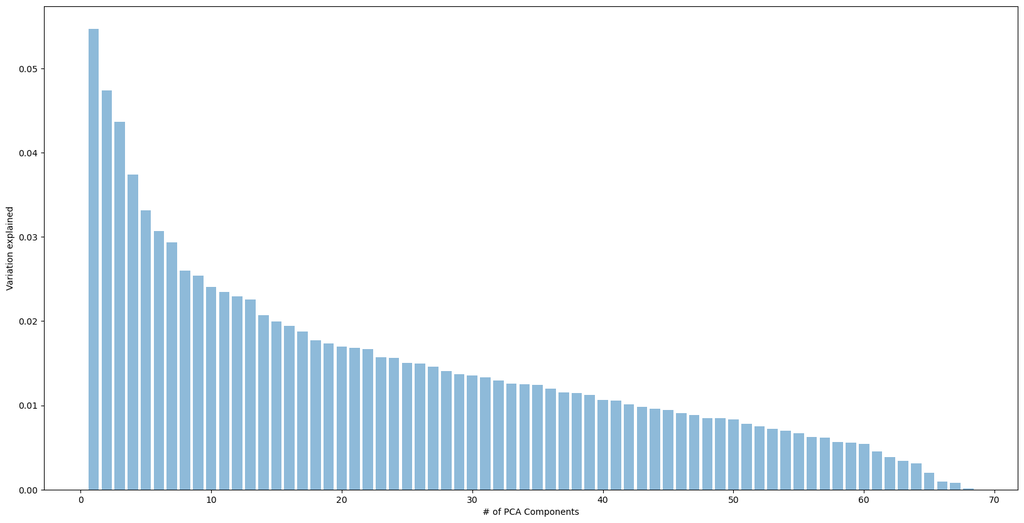

```python
pca = PCA(n_components=68)
pca.fit(X_train)

print("Eigen Vectors:",pca.components_)
print("Eigen Values:",pca.explained_variance_)

plt.figure(figsize=(20,10))
plt.bar(list(range(1,69)),pca.explained_variance_ratio_,alpha=0.5, align='center')
plt.ylabel('Variation explained')
plt.xlabel('# of PCA Components')
plt.show()
```

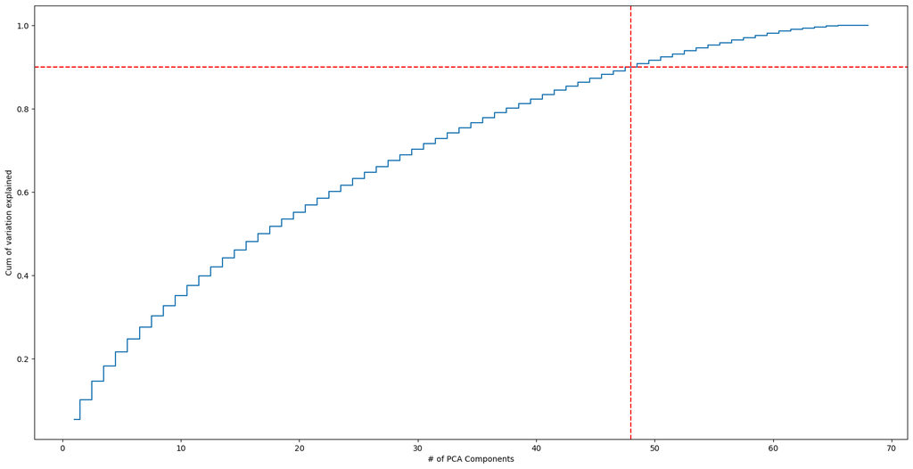

```python
plt.figure(figsize=(20,10))

plt.step(list(range(1,69)),np.cumsum(pca.explained_variance_ratio_), where='mid')
plt.axhline(y=0.9, color='r', linestyle='--', label='90% Threshold')
plt.axvline(x=48, color='r', linestyle='--', label='48 PCA components')

plt.ylabel('Cum of variation explained')
plt.xlabel('# of PCA Components')
```

- Cumulative sum of explained variances against the number of components can help to decide how many components to retain to capture a desired amount of variance. we should choose a threshold value of let's say 90% of variance explained) and select the number of components that achieve or exceed that threshold.
- In above case, 48 PCA components is explaining 90% of cummulative variance. So we will choose 48 pca components.

```python
pca48 = PCA(n_components=48)
pca48.fit(X_train)
print("Eigen Vectors:\n",pca48.components_)
print("Eigen Values:\n",pca48.explained_variance_)
print("Percentage of variation explained by each eigen Vector:\n",pca48.explained_variance_ratio_)
X_train_pca48 = pca48.transform(X_train)
X_test_pca48 = pca48.transform(X_test)
```

```
Eigen Vectors:
 [[-0.02151593 -0.0982905  -0.02584693 ... -0.04952127  0.04471954
   0.10928832]
 [ 0.07935434 -0.02196828  0.08973715 ... -0.06664946 -0.01710746
  -0.06309001]
 [ 0.06074911  0.06498629 -0.04932799 ...  0.19363942  0.06344245
  -0.05703298]
 ...
 [ 0.08842717  0.03531371 -0.2774116  ...  0.03677426  0.02333382
   0.25543749]
 [-0.15608477  0.05114521 -0.1653173  ... -0.1149806  -0.17813711
  -0.04760661]
 [ 0.33075249 -0.14146981 -0.17661622 ... -0.05190838  0.09100517
  -0.18884325]]
Eigen Values:
 [3.71967041 3.22684636 2.97323238 2.54254694 2.25450641 2.08848954
 1.99515862 1.76803175 1.72728475 1.6357336  1.59711307 1.55986557
 1.53540257 1.40951761 1.35887116 1.32016739 1.27856471 1.2073292
 1.18236004 1.15667214 1.14270196 1.13436176 1.06888966 1.06374441
 1.0234107  1.01830592 0.99071469 0.95638576 0.93025102 0.92162762
 0.90833134 0.88325753 0.85662468 0.8500725  0.84344582 0.81476417
 0.78564261 0.77773866 0.76251553 0.72390256 0.71715059 0.68508239
 0.6599185  0.64988595 0.64364528 0.61314775 0.59538396 0.57839566]
Percentage of variation explained by each eigen Vector:
 [0.0546761  0.04743199 0.04370408 0.03737335 0.03313939 0.03069908
 0.02932719 0.02598862 0.02538967 0.02404394 0.02347625 0.02292874
 0.02256916 0.02071875 0.01997429 0.01940538 0.01879385 0.01774675
 0.01737972 0.01700213 0.01679678 0.01667419 0.0157118  0.01563617
 0.0150433  0.01496826 0.01456269 0.01405809 0.01367393 0.01354717
 0.01335173 0.01298316 0.01259168 0.01249537 0.01239796 0.01197636
 0.0115483  0.01143212 0.01120835 0.01064077 0.01054153 0.01007015
 0.00970026 0.00955279 0.00946106 0.00901277 0.00875166 0.00850194]
```

```python
'''
    Defining a generic method to PCA train, predict and print different performance metrics(Accuracy, Precision, Recall, F1-Score),
    classification report and confustion matrix. We will use this method throughout this project.
'''
def PCAtrain_predict_perfscore_confmatrix(model, method):
    '''
    train, Predict, Print performance scores and confusion matrix for a classifier model.

    Parameters:
    - model: Classifier model
    - method: model name for testing.
    '''
    global performance_summary_all

    model.fit(X_train_pca48, Y_train) #train the model

    pred_train = model.predict(X_train_pca48) #predit on training data
    pred_test = model.predict(X_test_pca48)   #predit on testing data

    train_accuracy = model.score(X_train_pca48, Y_train) #score on training data
    test_accuracy = model.score(X_test_pca48, Y_test)    #score on testing data

    train_recall = metrics.recall_score(Y_train, pred_train) #recall on training data
    test_recall = metrics.recall_score(Y_test, pred_test)    #recall on testing data

    train_precision = metrics.precision_score(Y_train, pred_train) #precision on training data
    test_precision = metrics.precision_score(Y_test, pred_test)    #precision on testing data

    train_f1 = metrics.f1_score(Y_train, pred_train) #f1 score on training data
    test_f1 = metrics.f1_score(Y_test, pred_test)    #f1 score on testing data

    new_result = pd.DataFrame({
        'Method': [method],
        'train_accuracy': [train_accuracy],
        'train_recall': [train_recall],
        'train_precision': [train_precision],
        'train_f1': [train_f1],
        'test_accuracy': [test_accuracy],
        'test_recall': [test_recall],
        'test_precision': [test_precision],
        'test_f1': [test_f1]
    })
    # Concatenate new_result dataframe to existing global performance_summary_all which is used to record perforamnces of
    # each run. This variable will be used further whenever we want to do the comparision on performances of each run.
    performance_summary_all = pd.concat([performance_summary_all, new_result], ignore_index=True)
    # It should not duplicate values of same method when we re-run. it should keep the latest one and drop all previous ones.
    performance_summary_all.drop_duplicates(subset='Method', keep='last')

    print("================Performance Score================")
    print("Accuracy on training dataset : ", train_accuracy)
    print("Accuracy on test dataset : ", test_accuracy)

    print("\nRecall on training dataset : ", train_recall)
    print("Recall on test dataset : ", test_recall)

    print("\nPrecision on training dataset : ", train_precision)
    print("Precision on test dataset : ", test_precision)

    print("\nF1-Score on training dataset : ", train_f1)
    print("F1-Score on test dataset : ", test_f1)

    print("\n================Classfication Report for test data=============")
    print(metrics.classification_report(Y_test, pred_test))

    print("\n================Confusion Matrix for test data=================")
    cm = metrics.confusion_matrix(Y_test, pred_test, labels=[-1, 1])
    df_cm = pd.DataFrame(cm, index=['-1', ' 1'], columns=['Pred -1', 'Pred 1'])
    print(df_cm)
```

```python
param_grid = {
    'n_neighbors': [3, 5, 7],
    'weights': ['uniform', 'distance'],
    'p': [1, 2]
}
knn = KNeighborsClassifier()
grid_search = GridSearchCV(estimator=knn, param_grid=param_grid, cv=stratified_kfold)
grid_search.fit(X_train_pca48, Y_train)
best_params = grid_search.best_params_
print("Best Hyperparameters:", best_params)

best_model = grid_search.best_estimator_
print('Best Model', best_model)
```

```
Best Hyperparameters: {'n_neighbors': 3, 'p': 2, 'weights': 'uniform'}
Best Model KNeighborsClassifier(n_neighbors=3)
```

```python
PCAtrain_predict_perfscore_confmatrix(best_model, 'kNeighborsClassifier-GridSearchCV-PCA')
```

```
================Performance Score================
Accuracy on training dataset :  0.8988149498632635
Accuracy on test dataset :  0.5459183673469388

Recall on training dataset :  1.0
Recall on test dataset :  0.7692307692307693

Precision on training dataset :  0.8316906747536013
Precision on test dataset :  0.10416666666666667

F1-Score on training dataset :  0.908112582781457
F1-Score on test dataset :  0.1834862385321101

================Classfication Report for test data=============
              precision    recall  f1-score   support

          -1       0.97      0.53      0.69       366
           1       0.10      0.77      0.18        26

    accuracy                           0.55       392
   macro avg       0.54      0.65      0.43       392
weighted avg       0.91      0.55      0.65       392


================Confusion Matrix for test data=================
    Pred -1  Pred 1
-1      194     172
 1        6      20
```

#### F. Apply the above steps for all possible models that you have learnt so far. [5 Marks]

**Let us implement Logistic Regression**

```python
from sklearn.linear_model import LogisticRegression
```

```python
lr = LogisticRegression(solver="liblinear")

train_predict_perfscore_confmatrix(lr, 'LogisticRegression') #train, Predict, Print performance scores and confusion matrix for a classifier model.

print("=======K Fold Cross Validation========")
kfold = KFold(n_splits=5, shuffle=True, random_state=7)
cv_score = cross_val_score(lr, X_train, Y_train, cv=kfold)
print(cv_score)
print("Accuracy: Mean", cv_score.mean(),"Standard Deviation:", cv_score.std())

print("=======Leave One Out Cross-Validation=======")
lout = LeaveOneOut()
cv_score = cross_val_score(lr, X_train, Y_train, cv=lout)
print(cv_score)
print("Accuracy: Mean", cv_score.mean(),"Standard Deviation:", cv_score.std())

print("=======Stratified K fold cross-validation=======")
stratified_kfold = StratifiedKFold(n_splits = 5, shuffle=True)
cv_score = cross_val_score(lr, X_train, Y_train, cv=stratified_kfold, scoring='f1')
print(cv_score)
print("Accuracy: Mean", cv_score.mean(),"Standard Deviation:", cv_score.std())
```

```
================Performance Score================
Accuracy on training dataset :  0.8523245214220602
Accuracy on test dataset :  0.5637755102040817

Recall on training dataset :  0.8641750227894257
Recall on test dataset :  0.7692307692307693

Precision on training dataset :  0.8441674087266251
Precision on test dataset :  0.10810810810810811

F1-Score on training dataset :  0.854054054054054
F1-Score on test dataset :  0.1895734597156398

================Classfication Report for test data=============
              precision    recall  f1-score   support

          -1       0.97      0.55      0.70       366
           1       0.11      0.77      0.19        26

    accuracy                           0.56       392
   macro avg       0.54      0.66      0.45       392
weighted avg       0.91      0.56      0.67       392


================Confusion Matrix for test data=================
    Pred -1  Pred 1
-1      201     165
 1        6      20
=======K Fold Cross Validation========
[0.80182232 0.83826879 0.83826879 0.82687927 0.8652968 ]
Accuracy: Mean 0.8341071967214819 Standard Deviation: 0.020503586483657753
=======Leave One Out Cross-Validation=======
[1. 1. 1. ... 1. 1. 1.]
Accuracy: Mean 0.8359161349134002 Standard Deviation: 0.3703516576239971
=======Stratified K fold cross-validation=======
[0.83710407 0.8453159  0.81348315 0.84444444 0.83333333]
Accuracy: Mean 0.8347361800765635 Standard Deviation: 0.011536440576789224
```

```python
param_grid = {
    'penalty': ['l1', 'l2'],
    'C': [0.1, 1, 10],
    'solver': ['liblinear', 'saga'],
}

grid_search = GridSearchCV(estimator=lr, param_grid=param_grid, cv=stratified_kfold)
grid_search.fit(X_train, Y_train)
best_params = grid_search.best_params_
print("Best Hyperparameters:", best_params)

best_model = grid_search.best_estimator_
print('Best Model', best_model)

train_predict_perfscore_confmatrix(best_model, 'kNeighborsClassifier-GridSearchCV')
```

```
Best Hyperparameters: {'C': 10, 'penalty': 'l1', 'solver': 'liblinear'}
Best Model LogisticRegression(C=10, penalty='l1', solver='liblinear')
================Performance Score================
Accuracy on training dataset :  0.853236098450319
Accuracy on test dataset :  0.5688775510204082

Recall on training dataset :  0.8650865998176845
Recall on test dataset :  0.7692307692307693

Precision on training dataset :  0.8450578806767587
Precision on test dataset :  0.1092896174863388

F1-Score on training dataset :  0.854954954954955
F1-Score on test dataset :  0.19138755980861244

================Classfication Report for test data=============
              precision    recall  f1-score   support

          -1       0.97      0.55      0.71       366
           1       0.11      0.77      0.19        26

    accuracy                           0.57       392
   macro avg       0.54      0.66      0.45       392
weighted avg       0.91      0.57      0.67       392


================Confusion Matrix for test data=================
    Pred -1  Pred 1
-1      203     163
 1        6      20
```

```python
#Grid Search on X_train_pca48 training components
grid_search.fit(X_train_pca48, Y_train)
best_params = grid_search.best_params_
print("Best Hyperparameters:", best_params)

best_model = grid_search.best_estimator_
print('Best Model', best_model)

PCAtrain_predict_perfscore_confmatrix(best_model, 'LogisticRegression-GridSearchCV-PCA')
```

```
Best Hyperparameters: {'C': 1, 'penalty': 'l1', 'solver': 'liblinear'}
Best Model LogisticRegression(C=1, penalty='l1', solver='liblinear')
================Performance Score================
Accuracy on training dataset :  0.8035551504102096
Accuracy on test dataset :  0.5433673469387755

Recall on training dataset :  0.8149498632634458
Recall on test dataset :  0.8461538461538461

Precision on training dataset :  0.7967914438502673
Precision on test dataset :  0.1116751269035533

F1-Score on training dataset :  0.8057683641279856
F1-Score on test dataset :  0.19730941704035876

================Classfication Report for test data=============
              precision    recall  f1-score   support

          -1       0.98      0.52      0.68       366
           1       0.11      0.85      0.20        26

    accuracy                           0.54       392
   macro avg       0.55      0.68      0.44       392
weighted avg       0.92      0.54      0.65       392


================Confusion Matrix for test data=================
    Pred -1  Pred 1
-1      191     175
 1        4      22
```

**Let us implement Naive Bayes Model**

```python
from sklearn.naive_bayes import GaussianNB
```

```python
gnb = GaussianNB()

train_predict_perfscore_confmatrix(gnb, 'GaussianNaiveBayes') #train, Predict, Print performance scores and confusion matrix for a classifier model.

print("=======K Fold Cross Validation========")
kfold = KFold(n_splits=5, shuffle=True, random_state=7)
cv_score = cross_val_score(gnb, X_train, Y_train, cv=kfold)
print(cv_score)
print("Accuracy: Mean", cv_score.mean(),"Standard Deviation:", cv_score.std())

print("=======Leave One Out Cross-Validation=======")
lout = LeaveOneOut()
cv_score = cross_val_score(gnb, X_train, Y_train, cv=lout)
print(cv_score)
print("Accuracy: Mean", cv_score.mean(),"Standard Deviation:", cv_score.std())

print("=======Stratified K fold cross-validation=======")
stratified_kfold = StratifiedKFold(n_splits = 5, shuffle=True)
cv_score = cross_val_score(gnb, X_train, Y_train, cv=stratified_kfold, scoring='f1')
print(cv_score)
print("Accuracy: Mean", cv_score.mean(),"Standard Deviation:", cv_score.std())
```

```
================Performance Score================
Accuracy on training dataset :  0.8199635369188697
Accuracy on test dataset :  0.46683673469387754

Recall on training dataset :  0.8587055606198724
Recall on test dataset :  0.8461538461538461

Precision on training dataset :  0.7969543147208121
Precision on test dataset :  0.09691629955947137

F1-Score on training dataset :  0.8266783677051338
F1-Score on test dataset :  0.1739130434782609

================Classfication Report for test data=============
              precision    recall  f1-score   support

          -1       0.98      0.44      0.61       366
           1       0.10      0.85      0.17        26

    accuracy                           0.47       392
   macro avg       0.54      0.64      0.39       392
weighted avg       0.92      0.47      0.58       392


================Confusion Matrix for test data=================
    Pred -1  Pred 1
-1      161     205
 1        4      22
=======K Fold Cross Validation========
[0.80637813 0.81548975 0.77904328 0.80637813 0.6803653 ]
Accuracy: Mean 0.7775309181306622 Standard Deviation: 0.05009718872392879
=======Leave One Out Cross-Validation=======
[1. 1. 1. ... 1. 1. 1.]
Accuracy: Mean 0.8144940747493163 Standard Deviation: 0.38870744390553086
=======Stratified K fold cross-validation=======
[0.78787879 0.80503145 0.83111111 0.82678984 0.81385281]
Accuracy: Mean 0.812932799544155 Standard Deviation: 0.015578509823957079
```

Gaussian Naive Bayes does not have hyperparameters to tune through grid search, so we will fit on X_train_pca48 data

```python
PCAtrain_predict_perfscore_confmatrix(gnb, 'GaussianNaiveBayes-PCA')
```

```
================Performance Score================
Accuracy on training dataset :  0.8746581586144029
Accuracy on test dataset :  0.701530612244898

Recall on training dataset :  0.9115770282588879
Recall on test dataset :  0.34615384615384615

Precision on training dataset :  0.8488964346349746
Precision on test dataset :  0.08256880733944955

F1-Score on training dataset :  0.8791208791208791
F1-Score on test dataset :  0.13333333333333333

================Classfication Report for test data=============
              precision    recall  f1-score   support

          -1       0.94      0.73      0.82       366
           1       0.08      0.35      0.13        26

    accuracy                           0.70       392
   macro avg       0.51      0.54      0.48       392
weighted avg       0.88      0.70      0.77       392


================Confusion Matrix for test data=================
    Pred -1  Pred 1
-1      266     100
 1       17       9
```

**Let us implement SVM model:**

```python
from sklearn.svm import SVC
```

```python
svc = SVC() #build SVC model with default parameters

train_predict_perfscore_confmatrix(svc, 'SVM') #train, Predict, Print performance scores and confusion matrix for a classifier model.

print("=======K Fold Cross Validation========")
kfold = KFold(n_splits=5, shuffle=True, random_state=7)
cv_score = cross_val_score(svc, X_train, Y_train, cv=kfold)
print(cv_score)
print("Accuracy: Mean", cv_score.mean(),"Standard Deviation:", cv_score.std())

print("=======Leave One Out Cross-Validation=======")
lout = LeaveOneOut()
cv_score = cross_val_score(svc, X_train, Y_train, cv=lout)
print(cv_score)
print("Accuracy: Mean", cv_score.mean(),"Standard Deviation:", cv_score.std())

print("=======Stratified K fold cross-validation=======")
stratified_kfold = StratifiedKFold(n_splits = 5, shuffle=True)
cv_score = cross_val_score(svc, X_train, Y_train, cv=stratified_kfold, scoring='f1')
print(cv_score)
print("Accuracy: Mean", cv_score.mean(),"Standard Deviation:", cv_score.std())
```

```
================Performance Score================
Accuracy on training dataset :  0.9981768459434822
Accuracy on test dataset :  0.8596938775510204

Recall on training dataset :  1.0
Recall on test dataset :  0.2692307692307692

Precision on training dataset :  0.9963669391462306
Precision on test dataset :  0.16279069767441862

F1-Score on training dataset :  0.9981801637852593
F1-Score on test dataset :  0.2028985507246377

================Classfication Report for test data=============
              precision    recall  f1-score   support

          -1       0.95      0.90      0.92       366
           1       0.16      0.27      0.20        26

    accuracy                           0.86       392
   macro avg       0.55      0.59      0.56       392
weighted avg       0.89      0.86      0.88       392


================Confusion Matrix for test data=================
    Pred -1  Pred 1
-1      330      36
 1       19       7
=======K Fold Cross Validation========
[0.99088838 0.99088838 0.98861048 0.98861048 0.99315068]
Accuracy: Mean 0.9904296814054359 Standard Deviation: 0.001699627804180552
=======Leave One Out Cross-Validation=======
[1. 1. 1. ... 1. 1. 1.]
Accuracy: Mean 0.9931631722880584 Standard Deviation: 0.08240197509027855
=======Stratified K fold cross-validation=======
[0.98426966 0.98871332 0.99099099 0.99547511 0.99095023]
Accuracy: Mean 0.9900798623126559 Standard Deviation: 0.003642040079062772
```

```python
param_grid = {
    'C': [0.1, 1, 10],
    'kernel': ['linear', 'rbf'],
    'gamma': ['scale', 'auto'],
}

grid_search = GridSearchCV(estimator=svc, param_grid=param_grid, cv=kfold)
grid_search.fit(X_train, Y_train)
best_params = grid_search.best_params_
print("Best Hyperparameters:", best_params)

best_model = grid_search.best_estimator_
print('Best Model', best_model)

train_predict_perfscore_confmatrix(best_model, 'SVM-GridSearchCV')
```

```
Best Hyperparameters: {'C': 10, 'gamma': 'scale', 'kernel': 'rbf'}
Best Model SVC(C=10)
================Performance Score================
Accuracy on training dataset :  1.0
Accuracy on test dataset :  0.8954081632653061

Recall on training dataset :  1.0
Recall on test dataset :  0.2692307692307692

Precision on training dataset :  1.0
Precision on test dataset :  0.2413793103448276

F1-Score on training dataset :  1.0
F1-Score on test dataset :  0.2545454545454545

================Classfication Report for test data=============
              precision    recall  f1-score   support

          -1       0.95      0.94      0.94       366
           1       0.24      0.27      0.25        26

    accuracy                           0.90       392
   macro avg       0.59      0.60      0.60       392
weighted avg       0.90      0.90      0.90       392


================Confusion Matrix for test data=================
    Pred -1  Pred 1
-1      344      22
 1       19       7
```

Very good accuracy on training and test data.

```python
#Grid Search on X_train_pca48 training components
grid_search.fit(X_train_pca48, Y_train)
best_params = grid_search.best_params_
print("Best Hyperparameters:", best_params)

best_model = grid_search.best_estimator_
print('Best Model', best_model)

PCAtrain_predict_perfscore_confmatrix(best_model, 'SVM-GridSearchCV-PCA')
```

```
Best Hyperparameters: {'C': 10, 'gamma': 'auto', 'kernel': 'rbf'}
Best Model SVC(C=10, gamma='auto')
================Performance Score================
Accuracy on training dataset :  1.0
Accuracy on test dataset :  0.8571428571428571

Recall on training dataset :  1.0
Recall on test dataset :  0.2692307692307692

Precision on training dataset :  1.0
Precision on test dataset :  0.1590909090909091

F1-Score on training dataset :  1.0
F1-Score on test dataset :  0.19999999999999998

================Classfication Report for test data=============
              precision    recall  f1-score   support

          -1       0.95      0.90      0.92       366
           1       0.16      0.27      0.20        26

    accuracy                           0.86       392
   macro avg       0.55      0.58      0.56       392
weighted avg       0.89      0.86      0.87       392


================Confusion Matrix for test data=================
    Pred -1  Pred 1
-1      329      37
 1       19       7
```

Previous svc model found out after grid search without PCA components was better.

**Let us implement Decision Tree Classifier Model**

```python
from sklearn.tree import DecisionTreeClassifier
```

```python
dtree = DecisionTreeClassifier(random_state=1, max_depth=10)

train_predict_perfscore_confmatrix(dtree, 'DecisionTreeClassfier') #train, Predict, Print performance scores and confusion matrix for a classifier model.

print("=======K Fold Cross Validation========")
kfold = KFold(n_splits=5, shuffle=True, random_state=7)
cv_score = cross_val_score(dtree, X_train, Y_train, cv=kfold)
print(cv_score)
print("Accuracy: Mean", cv_score.mean(),"Standard Deviation:", cv_score.std())

print("=======Leave One Out Cross-Validation=======")
lout = LeaveOneOut()
cv_score = cross_val_score(dtree, X_train, Y_train, cv=lout)
print(cv_score)
print("Accuracy: Mean", cv_score.mean(),"Standard Deviation:", cv_score.std())

print("=======Stratified K fold cross-validation=======")
stratified_kfold = StratifiedKFold(n_splits = 5, shuffle=True)
cv_score = cross_val_score(dtree, X_train, Y_train, cv=stratified_kfold, scoring='f1')
print(cv_score)
print("Accuracy: Mean", cv_score.mean(),"Standard Deviation:", cv_score.std())
```

```
================Performance Score================
Accuracy on training dataset :  0.9831358249772105
Accuracy on test dataset :  0.5204081632653061

Recall on training dataset :  0.9963536918869644
Recall on test dataset :  0.6923076923076923

Precision on training dataset :  0.9706927175843695
Precision on test dataset :  0.09090909090909091

F1-Score on training dataset :  0.9833558254610886
F1-Score on test dataset :  0.16071428571428573

================Classfication Report for test data=============
              precision    recall  f1-score   support

          -1       0.96      0.51      0.66       366
           1       0.09      0.69      0.16        26

    accuracy                           0.52       392
   macro avg       0.52      0.60      0.41       392
weighted avg       0.90      0.52      0.63       392


================Confusion Matrix for test data=================
    Pred -1  Pred 1
-1      186     180
 1        8      18
=======K Fold Cross Validation========
[0.88610478 0.85421412 0.87243736 0.86788155 0.88584475]
Accuracy: Mean 0.8732965124140586 Standard Deviation: 0.011964176612628025
=======Leave One Out Cross-Validation=======
[1. 1. 1. ... 1. 1. 1.]
Accuracy: Mean 0.8933454876937101 Standard Deviation: 0.3086734962885498
=======Stratified K fold cross-validation=======
[0.86031042 0.8812095  0.87772926 0.88596491 0.88691796]
Accuracy: Mean 0.8784264109074174 Standard Deviation: 0.009647342805363768
```

```python
param_grid = {
    'max_depth': [5, 10, 15],
    'min_samples_split': [2, 5],
    'min_samples_leaf': [1, 2, 4]
}

grid_search = GridSearchCV(estimator=dtree, param_grid=param_grid, cv=stratified_kfold)
grid_search.fit(X_train, Y_train)
best_params = grid_search.best_params_
print("Best Hyperparameters:", best_params)

best_model = grid_search.best_estimator_
print('Best Model', best_model)

train_predict_perfscore_confmatrix(best_model, 'DecisionTreeClassfier-GridSearchCV')
```

```
Best Hyperparameters: {'max_depth': 15, 'min_samples_leaf': 2, 'min_samples_split': 2}
Best Model DecisionTreeClassifier(max_depth=15, min_samples_leaf=2, random_state=1)
================Performance Score================
Accuracy on training dataset :  0.9867821330902461
Accuracy on test dataset :  0.5688775510204082

Recall on training dataset :  0.9808568824065633
Recall on test dataset :  0.6923076923076923

Precision on training dataset :  0.992619926199262
Precision on test dataset :  0.1005586592178771

F1-Score on training dataset :  0.9867033470884916
F1-Score on test dataset :  0.175609756097561

================Classfication Report for test data=============
              precision    recall  f1-score   support

          -1       0.96      0.56      0.71       366
           1       0.10      0.69      0.18        26

    accuracy                           0.57       392
   macro avg       0.53      0.63      0.44       392
weighted avg       0.91      0.57      0.67       392


================Confusion Matrix for test data=================
    Pred -1  Pred 1
-1      205     161
 1        8      18
```

```python
#Grid Search on X_train_pca48 training components
grid_search.fit(X_train_pca48, Y_train)
best_params = grid_search.best_params_
print("Best Hyperparameters:", best_params)

best_model = grid_search.best_estimator_
print('Best Model', best_model)

PCAtrain_predict_perfscore_confmatrix(best_model, 'DecisionTreeClassfier-GridSearchCV-PCA')
```

```
Best Hyperparameters: {'max_depth': 15, 'min_samples_leaf': 1, 'min_samples_split': 5}
Best Model DecisionTreeClassifier(max_depth=15, min_samples_split=5, random_state=1)
================Performance Score================
Accuracy on training dataset :  0.97538742023701
Accuracy on test dataset :  0.7040816326530612

Recall on training dataset :  0.9936189608021878
Recall on test dataset :  0.15384615384615385

Precision on training dataset :  0.9586631486367634
Precision on test dataset :  0.04081632653061224

F1-Score on training dataset :  0.9758281110116384
F1-Score on test dataset :  0.06451612903225806

================Classfication Report for test data=============
              precision    recall  f1-score   support

          -1       0.93      0.74      0.82       366
           1       0.04      0.15      0.06        26

    accuracy                           0.70       392
   macro avg       0.48      0.45      0.44       392
weighted avg       0.87      0.70      0.77       392


================Confusion Matrix for test data=================
    Pred -1  Pred 1
-1      272      94
 1       22       4
```

**Let us try Bagging Classifier Model from ensemble technique**

```python
from sklearn.ensemble import BaggingClassifier
```

```python
bgc = BaggingClassifier(random_state=1) #build model with default parameter values

train_predict_perfscore_confmatrix(bgc, 'BaggingClassifier') #train, Predict, Print performance scores and confusion matrix for a classifier model.

print("=======K Fold Cross Validation========")
kfold = KFold(n_splits=5, shuffle=True, random_state=7)
cv_score = cross_val_score(bgc, X_train, Y_train, cv=kfold)
print(cv_score)
print("Accuracy: Mean", cv_score.mean(),"Standard Deviation:", cv_score.std())

print("=======Stratified K fold cross-validation=======")
stratified_kfold = StratifiedKFold(n_splits = 5, shuffle=True)
cv_score = cross_val_score(bgc, X_train, Y_train, cv=stratified_kfold, scoring='f1')
print(cv_score)
print("Accuracy: Mean", cv_score.mean(),"Standard Deviation:", cv_score.std())
```

```
================Performance Score================
Accuracy on training dataset :  0.9986326344576116
Accuracy on test dataset :  0.6377551020408163

Recall on training dataset :  0.9990884229717412
Recall on test dataset :  0.6153846153846154

Precision on training dataset :  0.9981785063752276
Precision on test dataset :  0.10810810810810811

F1-Score on training dataset :  0.998633257403189
F1-Score on test dataset :  0.1839080459770115

================Classfication Report for test data=============
              precision    recall  f1-score   support

          -1       0.96      0.64      0.77       366
           1       0.11      0.62      0.18        26

    accuracy                           0.64       392
   macro avg       0.53      0.63      0.48       392
weighted avg       0.90      0.64      0.73       392


================Confusion Matrix for test data=================
    Pred -1  Pred 1
-1      234     132
 1       10      16
=======K Fold Cross Validation========
[0.95444191 0.93849658 0.95671982 0.93849658 0.9543379 ]
Accuracy: Mean 0.9484985594075368 Standard Deviation: 0.008210840368307135
=======Stratified K fold cross-validation=======
[0.93877551 0.94808126 0.95022624 0.92840647 0.9476082 ]
Accuracy: Mean 0.9426195371249216 Standard Deviation: 0.008116244665846477
```

```python
param_grid = {
    'n_estimators': [10, 50, 100],
    'max_samples': [0.5, 1.0],
    'max_features': [0.5, 1.0],
}

grid_search = GridSearchCV(estimator=bgc, param_grid=param_grid, cv=kfold)
grid_search.fit(X_train, Y_train)
best_params = grid_search.best_params_
print("Best Hyperparameters:", best_params)

best_model = grid_search.best_estimator_
print('Best Model', best_model)

train_predict_perfscore_confmatrix(best_model, 'BaggingClassifier-GridSearchCV')
```

```
Best Hyperparameters: {'max_features': 0.5, 'max_samples': 1.0, 'n_estimators': 100}
Best Model BaggingClassifier(max_features=0.5, n_estimators=100, random_state=1)
================Performance Score================
Accuracy on training dataset :  1.0
Accuracy on test dataset :  0.5688775510204082

Recall on training dataset :  1.0
Recall on test dataset :  0.6153846153846154

Precision on training dataset :  1.0
Precision on test dataset :  0.09142857142857143

F1-Score on training dataset :  1.0
F1-Score on test dataset :  0.15920398009950248

================Classfication Report for test data=============
              precision    recall  f1-score   support

          -1       0.95      0.57      0.71       366
           1       0.09      0.62      0.16        26

    accuracy                           0.57       392
   macro avg       0.52      0.59      0.43       392
weighted avg       0.90      0.57      0.67       392


================Confusion Matrix for test data=================
    Pred -1  Pred 1
-1      207     159
 1       10      16
```

Not a very good score, Let us try on pca data.

```python
#Grid Search on X_train_pca48 training components
grid_search.fit(X_train_pca48, Y_train)
best_params = grid_search.best_params_
print("Best Hyperparameters:", best_params)

best_model = grid_search.best_estimator_
print('Best Model', best_model)

PCAtrain_predict_perfscore_confmatrix(best_model, 'BaggingClassifier-GridSearchCV-PCA')
```

```
Best Hyperparameters: {'max_features': 0.5, 'max_samples': 1.0, 'n_estimators': 100}
Best Model BaggingClassifier(max_features=0.5, n_estimators=100, random_state=1)
================Performance Score================
Accuracy on training dataset :  1.0
Accuracy on test dataset :  0.8775510204081632

Recall on training dataset :  1.0
Recall on test dataset :  0.038461538461538464

Precision on training dataset :  1.0
Precision on test dataset :  0.041666666666666664

F1-Score on training dataset :  1.0
F1-Score on test dataset :  0.04

================Classfication Report for test data=============
              precision    recall  f1-score   support

          -1       0.93      0.94      0.93       366
           1       0.04      0.04      0.04        26

    accuracy                           0.88       392
   macro avg       0.49      0.49      0.49       392
weighted avg       0.87      0.88      0.88       392


================Confusion Matrix for test data=================
    Pred -1  Pred 1
-1      343      23
 1       25       1
```

- Good accuracy but recall precision and f1 score is not good.
- Prediction for -1 pass is quite good having above 93% score.
- but for 1 fail class it is not predicting well.

**Let us implement RandomForestClassifier model**

```python
from sklearn.ensemble import RandomForestClassifier
```

```python
rfcl = RandomForestClassifier(random_state=1)
train_predict_perfscore_confmatrix(rfcl, 'RandomForestClassifier')
```

```
================Performance Score================
Accuracy on training dataset :  1.0
Accuracy on test dataset :  0.6632653061224489

Recall on training dataset :  1.0
Recall on test dataset :  0.6538461538461539

Precision on training dataset :  1.0
Precision on test dataset :  0.12142857142857143

F1-Score on training dataset :  1.0
F1-Score on test dataset :  0.20481927710843373

================Classfication Report for test data=============
              precision    recall  f1-score   support

          -1       0.96      0.66      0.79       366
           1       0.12      0.65      0.20        26

    accuracy                           0.66       392
   macro avg       0.54      0.66      0.50       392
weighted avg       0.91      0.66      0.75       392


================Confusion Matrix for test data=================
    Pred -1  Pred 1
-1      243     123
 1        9      17
```

```python
#RandomForestClassifier model training and rpediction on pca components data
PCAtrain_predict_perfscore_confmatrix(rfcl, 'RandomForestClassifier-PCA')
```

```
================Performance Score================
Accuracy on training dataset :  1.0
Accuracy on test dataset :  0.8647959183673469

Recall on training dataset :  1.0
Recall on test dataset :  0.038461538461538464

Precision on training dataset :  1.0
Precision on test dataset :  0.034482758620689655

F1-Score on training dataset :  1.0
F1-Score on test dataset :  0.03636363636363637

================Classfication Report for test data=============
              precision    recall  f1-score   support

          -1       0.93      0.92      0.93       366
           1       0.03      0.04      0.04        26

    accuracy                           0.86       392
   macro avg       0.48      0.48      0.48       392
weighted avg       0.87      0.86      0.87       392


================Confusion Matrix for test data=================
    Pred -1  Pred 1
-1      338      28
 1       25       1
```

Accuracy is not that good on test data compared to the train data.  
it is not able to predit True Negative Fail correctly.

#### 6. Post Training and Conclusion: [5 Marks]

#### A. Display and compare all the models designed with their train and test accuracies. [1 Marks]

While training and predicting all the models, we stored all the results in performance_summary_all dataframe. we will use that for comparision.

```python
performance_summary_all
```

|  | Method | train_accuracy | train_recall | train_precision | train_f1 | test_accuracy | test_recall | test_precision | test_f1 |
| --- | --- | --- | --- | --- | --- | --- | --- | --- | --- |
| 0 | KNeighborsClassifier | 0.816773 | 1.000000 | 0.731821 | 0.845146 | 0.400510 | 0.884615 | 0.090196 | 0.163701 |
| 1 | kNeighborsClassifier-GridSearchCV | 0.942115 | 1.000000 | 0.896242 | 0.945282 | 0.622449 | 0.730769 | 0.118750 | 0.204301 |
| 2 | kNeighborsClassifier-GridSearchCV-PCA | 0.898815 | 1.000000 | 0.831691 | 0.908113 | 0.545918 | 0.769231 | 0.104167 | 0.183486 |
| 3 | LogisticRegression | 0.852325 | 0.864175 | 0.844167 | 0.854054 | 0.563776 | 0.769231 | 0.108108 | 0.189573 |
| 4 | kNeighborsClassifier-GridSearchCV | 0.853236 | 0.865087 | 0.845058 | 0.854955 | 0.568878 | 0.769231 | 0.109290 | 0.191388 |
| 5 | LogisticRegression-GridSearchCV-PCA | 0.803555 | 0.814950 | 0.796791 | 0.805768 | 0.543367 | 0.846154 | 0.111675 | 0.197309 |
| 6 | GaussianNaiveBayes | 0.819964 | 0.858706 | 0.796954 | 0.826678 | 0.466837 | 0.846154 | 0.096916 | 0.173913 |
| 7 | GaussianNaiveBayes-PCA | 0.874658 | 0.911577 | 0.848896 | 0.879121 | 0.701531 | 0.346154 | 0.082569 | 0.133333 |
| 8 | SVM | 0.998177 | 1.000000 | 0.996367 | 0.998180 | 0.859694 | 0.269231 | 0.162791 | 0.202899 |
| 9 | SVM-GridSearchCV | 1.000000 | 1.000000 | 1.000000 | 1.000000 | 0.895408 | 0.269231 | 0.241379 | 0.254545 |
| 10 | SVM-GridSearchCV-PCA | 1.000000 | 1.000000 | 1.000000 | 1.000000 | 0.857143 | 0.269231 | 0.159091 | 0.200000 |
| 11 | DecisionTreeClassfier | 0.983136 | 0.996354 | 0.970693 | 0.983356 | 0.520408 | 0.692308 | 0.090909 | 0.160714 |
| 12 | DecisionTreeClassfier-GridSearchCV | 0.986782 | 0.980857 | 0.992620 | 0.986703 | 0.568878 | 0.692308 | 0.100559 | 0.175610 |
| 13 | DecisionTreeClassfier-GridSearchCV-PCA | 0.975387 | 0.993619 | 0.958663 | 0.975828 | 0.704082 | 0.153846 | 0.040816 | 0.064516 |
| 15 | BaggingClassifier | 0.998633 | 0.999088 | 0.998179 | 0.998633 | 0.637755 | 0.615385 | 0.108108 | 0.183908 |
| 16 | BaggingClassifier-GridSearchCV | 1.000000 | 1.000000 | 1.000000 | 1.000000 | 0.568878 | 0.615385 | 0.091429 | 0.159204 |
| 17 | BaggingClassifier-GridSearchCV-PCA | 1.000000 | 1.000000 | 1.000000 | 1.000000 | 0.877551 | 0.038462 | 0.041667 | 0.040000 |
| 18 | RandomForestClassifier | 1.000000 | 1.000000 | 1.000000 | 1.000000 | 0.663265 | 0.653846 | 0.121429 | 0.204819 |
| 19 | RandomForestClassifier-PCA | 1.000000 | 1.000000 | 1.000000 | 1.000000 | 0.864796 | 0.038462 | 0.034483 | 0.036364 |

#### B. Select the final best trained model along with your detailed comments for selecting this model. [1 Marks]

Looking at all the above comparision of all the models tried out so far, the best model seems to be:

- SVM-GridSearchCV score for train_accuracy, train_recall, train_precision, train_f1, test_accuracy, test_recall, test_precision, test_f1 are 1.000000, 1.000000, 1.000000, 1.000000, 0.895408, 0.269231, 0.241379, 0.254545 respectively.
- Train Accuracy, Recall, Precision, F1 All have perfect scores of 1. This indicates that the model is performing extremely well on the training data, correctly predicting all instances of both classes -1(pass), 1(fail) with high precision and recall.
- Test accuracy is 0.895408, which is relatively high. It indicates that the model is performing well on unseen data and correctly classifying approximately 89.5% of the instances, which no other model is prediciting so well on test data.
- Test recall is 0.269231 which suggests that the model is able to correctly identify around 26.92% of the failed cases i.e 1 out of all actual failed cases in the test set.
- Test precision is 0.241379, which is relatively low. It means that out of all instances predicted as failed i.e 1 by the model, only approximately 24.14% are actually true failures.
- Below is the classification report and confusion matrix for this model.

```
================Classfication Report for test data=============
              precision    recall  f1-score   support

          -1       0.95      0.94      0.94       366
           1       0.24      0.27      0.25        26

    accuracy                           0.90       392
   macro avg       0.59      0.60      0.60       392
weighted avg       0.90      0.90      0.90       392
```

```
================Confusion Matrix for test data=================
    Pred -1  Pred 1
-1      344      22
 1       19       7
```

- If we look at the confusion matrix, it has correctly predicted 344 pass(True Positive), and correctly predicted 7 fails(True Negative).
- It made mistake while predicting with 22 and 19 data points. 22 was identified as fail but they were actually pass.
- 19 was actually fail but model predicted it as pass.
- but the number of mistakes in prediction is very less than number of correct predictions. Hence I think it is the best model.
- If we look at the classification report as well, prediction for pass is quite good around 95% with similar recall and precision for pass. but yes for fail it is quite low but comparatively better than other models trained.

#### C. Pickle the selected model for future use. [2 Marks]

```python
#Let us rebuild the model as that that model instance is overriden by other models.
svc = SVC(C=10, gamma='scale', kernel='rbf')

kfold = KFold(n_splits=5, shuffle=True, random_state=7)
cv_score = cross_val_score(svc, X_train, Y_train, cv=kfold)
print(cv_score)
print("Accuracy: Mean", cv_score.mean(),"Standard Deviation:", cv_score.std())

svc.fit(X_train, Y_train)
pred_class = svc.predict(X_test)

print(svc.score(X_train, Y_train))
print(svc.score(X_test, Y_test))
```

```
[0.99544419 0.99316629 0.99088838 0.99316629 0.99771689]
Accuracy: Mean 0.99407640860819 Standard Deviation: 0.0023213841779683893
1.0
0.8954081632653061
```

We have built that model again. now we will pickle this for future use.

```python
import pickle
#pickling the svm model into a file named svm_gscv.pkl by opening it in write binary mode and dumping it on drive.
with open('svm_gscv.pkl', 'wb') as file:
    pickle.dump(svc, file)
```

```python
#now if we wish to load the pickled model in memory for use
with open('svm_gscv.pkl', 'rb') as file:
    svm_loaded = pickle.load(file)
```

let us see if loaded svm model works.

```python
svm_loaded.score(X_test, Y_test)
```

```
0.8954081632653061
```

It worked.